# Lecture 4：異質性のある需要と合併分析

計量経済学II

作者

Kei Ikegami

**重要この講義で押さえたいこと**

- **属性への評価や価格への反応を消費者ごとに変える**と、商品の代替関係がどう変わるかを理解する。同じ販売数を再現していても、好みの構造が違えば値上げ後の需要は異なり得る。
- random coefficient logit の選択確率を人々について平均し、市場全体の需要を計算する。この平均を**数値積分**で求める。
- 第3回の「Berry反転とIV」を、係数に異質性のあるモデルへ拡張する。小さな数値例で、**BLPによる需要推定**の手順を追う。
- 推定した需要に企業の価格設定行動を加え、**合併後の価格と消費者余剰**を予測する。需要の推定と合併分析を、一つの例でつなげる。
- 購入者の所得や第二希望を使う **micro BLP** を学ぶ。販売数だけでなく「誰が買ったか」「ほかに何を買いたかったか」を使うと、好みの違いについて何が分かるだろうか。

## 前回とのつながり・今回のゴール

第3回では、第2回で学んだ logit を使って需要を推定する際の、2つの問題を扱った。一つは、どの商品からどの商品へ需要が移るかをモデルが強く制約してしまうこと。もう一つは、価格が分析者には見えない需要ショックに反応して決まる、価格の内生性である。今回は、この両方の話を引き継ぐ。

まず、代替関係の問題を振り返ろう。plain logit には IIA（無関係な選択肢からの独立性）があり、他の価格や属性を固定して財3だけを値上げすると、財1と財2の需要の増加分の比は、両者の元のシェア比で決まる。財1の方が財3に似ているとしても、その近さを別に反映できない。前回の nested logit では、同じネストに属する財の効用ショックに相関を許すことで、この制約を緩めた。ただし、**どの財を同じネストに入れるかは分析者が事前に決める**必要があり、同じネスト内の2財のシェア比にはIIAが残る。

今回は、ネストを指定する代わりに、**属性への評価や価格への反応を表す係数を、消費者ごとに変える**。これまでも、効用ショックを通じて人による好みの違いを表していた。新しく加えるのは、例えば甘さを評価する係数そのものが人によって違い、甘いコーヒーを好む人は複数の甘い商品を高く評価する、という関係である。価格への反応にも人による違いを認める。こうしたモデルを random coefficient logit と呼ぶ。

次に、価格の内生性である。前回は、**Berry反転でシェアから平均効用を取り出し、その式にIVを使う**ことで対処した。反転は需要ショックを取り出せる形を作るための操作であり、価格と需要ショックの相関に対処するには、妥当な操作変数が必要だった。係数を消費者ごとに変えても、この内生性の問題は残る。

そこで今回は、random coefficient logit でも同じ推定の考え方を使いたい。ただし、消費者ごとの選択確率を平均してシェアを求めるため、前回の logit のようにシェアの対数差だけで平均効用を取り出すことはできない。係数の分布を表すパラメータを仮に決め、観測シェアを再現する平均効用を数値計算で逆算する。その上で、取り出した需要ショックと操作変数が無相関になる条件を使って推定する。これが、今回学ぶ**BLPの推定方法**につながる。

Lecture 4では、まず係数の異質性が代替関係をどう変えるかを確かめ、BLPで需要を推定する。次に、その需要を企業の価格設定のモデルに入れ、**合併したら価格がどれだけ上がるか**を計算する。最後に、個票データを追加するmicro BLPを取り上げる。合併予測に必要な代替関係を、「誰がどの商品を買ったか」という情報からも調べるためである。

需要推定と合併分析は、第5回のゲスト講義で扱う合併審査を理解するための準備になる。

計算の手順は少し長いが、「需要を推定する」「推定した需要で合併後を予測する」「需要の推定に使う情報を増やす」という順に追っていこう。

## 1. なぜ係数を消費者ごとに変えるのか

コンビニにブラック、微糖、カフェオレの3種類が並んでいるとする。消費者はどれかを買うか、「買わない」（outside option）を選ぶ。ここで微糖が10円値上げされたらどうなるだろうか。plain logit では、微糖からブラックとカフェオレへ移る需要の比率は、両者の市場シェアの比で決まる。

しかし、微糖を選ぶ人の多くが甘さを好むなら、値上げ後の候補としてブラックよりカフェオレを高く評価するかもしれない。このような代替を表す一つの方法が、**人によって甘さの好みが違う**ことをモデルに入れることである。すなわち、第2回の $x_j'\beta$ の $\beta$ を、人ごとの $\beta_i$ に変える、というモデルを考える。

さらに、属性に対してだけでなく、価格への反応も人によって違うのが普通である。例えば、所得の高い人は10円の値上げをあまり気にしない（$\alpha_i$ が小さい）が、学生は気にする（$\alpha_i$ が大きい）、というような状況がある。この異質性を入れると、もともと価格をあまり気にしない人ほど高い財を買いやすくなる。企業の価格設定に際して、価格への反応がどのように人によって異なるかは極めて重要な情報であることは疑いの余地はない。その意味でもRandome coefficient logitは考えるに値するモデルであると言える。

**ノートビジネスの現場で：自社ラインナップのカニバリゼーション**

新商品を出すときには、自社のどの既存商品から客が移るかも知りたい。これが**カニバリゼーション（cannibalization）**の問題である。plain logit では、どの商品から移るかはシェアの比率で決まってしまう。しかし「濃いめのカフェオレ」を発売したなら、ブラックよりも微糖や既存のカフェオレから客が移りやすいと考えられる。random coefficient logit では、属性への好みの違いを使って、どの自社製品の需要がどれだけ減るかを予測する。この予測は、価格改定や品揃え（assortment）の最適化にも使われる。

### 差別化：垂直的差別化と水平的差別化

Randome coefficient logitの話に入る前に、「異なる製品」の意味内容をもうちょっと考えておくと後々話がしやすくなる。

経済学では製品が異なっていることを**差別化**されているという。そしてこの差別化には二種類ある。 製品の違いを、**価格を同じにそろえたとき、消費者の製品順位が一致するか**という観点から整理しよう。同じ価格なら全員が同じ品質順位で評価する場合を**垂直的差別化**、好みによって製品の順位が異なる場合を**水平的差別化**と呼ぶ。

ここでは、両者からどんな需要が生まれるかを、3人の買い物の例で確かめよう。いずれも説明用の架空の市場であり、効用を「評価額−価格」として円単位で測る。買わない効用は0とし、ランダム項は一旦省く。後でこの例を random coefficient logit につなげる。

#### 垂直的差別化：同じ価格なら全員が高品質を好む

Aは品質1、Bは品質2のコーヒーとする。品質1単位に払ってよいと思う金額が、3人それぞれ120円、160円、220円だとしよう。BはAの2倍の品質なので、それぞれの評価額も2倍になる。

| 消費者 | Aの評価額 | Bの評価額 | Aが100円、Bが250円のときの効用と選択 | Bだけ300円にしたときの効用と選択 |
| --- | --- | --- | --- | --- |
| 1人目 | 120円 | 240円 | A：20、B：−10 → **A** | A：20、B：−60 → **A** |
| 2人目 | 160円 | 320円 | A：60、B：70 → **B** | A：60、B：20 → **A** |
| 3人目 | 220円 | 440円 | A：120、B：190 → **B** | A：120、B：140 → **B** |

例えば2人目は、値上げ前には $320-250=70$ が $160-100=60$ より大きいのでBを買う。値上げ後にはBの効用が $320-300=20$ に下がるのでAに移る。3人の選択を数えると、**需要はAが1本・Bが2本から、Aが2本・Bが1本へ変わる**。

AもBも100円だったら、3人ともBを選ぶ。**同じ価格なら、全員が同じ品質順位で製品を評価する**のが、この垂直的差別化の例である。好みが完全に同じという意味ではなく、追加の品質にいくら払うかは人によって異なる。品質を $z_j$、人 $i$ の品質1単位への評価を $w_i>0$ とすれば、効用は $u_{ij}=w_i z_j-p_j$ と書ける。すでにこのモデルにも、品質への支払意思額の異質性がある。

#### 水平的差別化：同じ価格でも好きな製品が違う

今度はAを「苦いコーヒー」、Bを「甘いコーヒー」と考える。苦い方が好きな人も、甘い方が好きな人もいる。次の評価額を持つ3人を考えよう。

| 消費者 | Aの評価額 | Bの評価額 | Aが100円、Bが250円のときの効用と選択 | Bだけ300円にしたときの効用と選択 |
| --- | --- | --- | --- | --- |
| 1人目 | 160円 | 80円 | A：60、B：−170 → **A** | A：60、B：−220 → **A** |
| 2人目 | 120円 | 360円 | A：20、B：110 → **B** | A：20、B：60 → **B** |
| 3人目 | 160円 | 400円 | A：60、B：150 → **B** | A：60、B：100 → **B** |

同じ100円にそろえても、1人目はA、2・3人目はBを選ぶ。**同じ価格でも、人によって製品の好ましさの順位が違う**のが、この水平的差別化の例である。

値上げ前の需要は、先ほどと同じAが1本・Bが2本である。しかし、この例ではBを300円にしても2・3人目はBを選び続け、需要は変わらない。同じ現在の販売数を説明できても、好みのモデルが違えば、値上げ後の需要予測は違う。水平的差別化なら必ず価格に反応しにくいという意味ではなく、**現在のシェアだけでは代替関係は決まらない**、という例である。

#### Bresnahanの需要モデルから、属性への評価が異なるモデルへ

垂直的差別化を使って需要を考えた研究に、[Bresnahan (1987)](https://doi.org/10.2307/2098583)の自動車需要の分析がある。製品 $j$ の品質を $z_j$、消費者 $i$ の品質1単位への支払意思額を $w_i>0$ とすれば、車を買ったときの効用は、車以外の消費に使う所得を含めて

$$u_{ij}=w_i z_j+y_i-p_j$$

と書ける。車を買う場合同士を比べると、所得 $y_i$ は共通なので、選択は $w_i z_j-p_j$ の大小で決まる。品質への支払意思額 $w_i$ は人によって異なるが、$z_B>z_A$ なら、同じ価格では全員がBをAより高く評価する。つまり、これは**垂直的差別化**のモデルである。それでも、高品質のBが高い価格で売られていれば、品質に高い金額を払いたい人はBを選び、そうでない人はAを選ぶことがある。車を買わないという選択肢も含めて、こうした個人の選択を集計すると需要が得られる。

では、第2回・第3回で使ったlogitはどうだろうか。製品属性への係数を $\beta$ として、効用は

$$u_{ij}=x_j'\beta-\alpha p_j+\xi_j+\varepsilon_{ij}$$

と書けた。ここで、人ごと・製品ごとのショック $\varepsilon_{ij}$ をいったん除いて考えよう。属性への係数 $\beta$ と価格係数 $\alpha>0$ は全員に共通しているので、同じ価格なら、$x_j'\beta+\xi_j$ の大きさに従って、全員が同じ順位で製品を評価する。この部分だけを見ると、製品は共通の順位に沿って並んでいる。つまり、**垂直的差別化**である。

では、**水平的差別化**を表すにはどうすればよいだろうか。一つ目の方法は、いったん除いた $\varepsilon_{ij}$ を戻すことである。この項には、分析者には観測できない人ごと・製品ごとの好みが含まれる。この項が人と製品の組み合わせによって異なれば、同じ価格でも、ある人はAを、別の人はBを高く評価し得る。これまでのlogitにも、水平的な好みの違いは入っていたわけだ。

しかし、通常のlogitでは、そうした好みの違いを $\varepsilon_{ij}$ にまとめているため、例えば「甘いものを好む人は、複数の甘い商品を高く評価する」という関係を、商品属性と結びつけて表していない。第3回で見たように、独立な $\varepsilon_{ij}$ を仮定した通常のlogitでは、ある商品の値上げで失われた需要が他の商品へ移る割合は、それらの市場シェアに比例する。企業の価格設定にも需要予測は使えるが、**どの商品同士が消費者にとって近い代替品なのか**を、それぞれの属性に基づいて十分に反映することはできない。

そこで、二つ目の方法として **random coefficient logit** を考える。これは $\varepsilon_{ij}$ も残したうえで、共通だった属性の係数 $\beta$ を消費者ごとの $\beta_i$ に変える。例えば甘さへの評価を人によって変えれば、甘いものを好む人が複数の甘い商品を高く評価するという関係を表せる。こうして水平的な好みの違いを商品属性と結びつけることで、価格が変わったときに、どの商品からどの商品へ需要が移りやすいかを考えるのである。

## 2. モデル：random coefficient logit

記法は第2回・第3回と同じである。消費者を $i$、財を $j$（$j=0$ は「買わない」という outside option）、市場を $t$ と書く。効用は次のようになる。

$$u_{ijt} = x_{jt}'\beta_i - \alpha_i\, p_{jt} + \xi_{jt} + \varepsilon_{ijt}.$$

これまでの logit との違いは、係数に $i$ の添字が付いたことである。$\varepsilon_{ijt}$ はこれまで通り Type I 極値分布（Gumbel）に従う。選択肢間で独立であり、係数を決める消費者のタイプとも独立とする。$\xi_{jt}$ は分析者には観測できない製品・市場の魅力であり、第3回で価格の内生性を考えるときに使った項である。

属性への評価が人によって違うことを、次の式で表す。

$$\beta_i = \beta + \Sigma^{1/2}\nu_i, \qquad \nu_i \sim N(0, I).$$

$\beta$ は平均的な好み、$\Sigma$ は好みのばらつきを表し、その対角成分が異質性の大きさに対応する。$\nu_i$ は消費者ごとの違いを表す乱数である。

### 価格係数には対数正規分布を使う

価格係数 $\alpha_i$ に正規分布を仮定すると、分布の裾では $\alpha_i < 0$ となる人も出てくる。効用の式には価格がマイナスで入っているので、この人は価格が上がるほど効用が高くなってしまう。そこで、**対数正規分布**を使い、価格係数が常に正になるようにする。

$$\alpha_i = \exp(\bar\alpha + \sigma\, \nu_i^{p}), \qquad \nu_i^{p} \sim N(0,1).$$

$\bar\alpha$ は **log価格係数の平均**、$\sigma$ はlog価格係数の標準偏差である。元の水準では

$$\operatorname{median}(\alpha_i)=e^{\bar\alpha},\qquad
E[\alpha_i]=e^{\bar\alpha+\sigma^2/2}.$$

したがって、$e^{\bar\alpha}$ は一般には平均価格係数ではない。平均と一致するのは $\sigma=0$ のときだけである。この区別に注意しよう。Nevo (2000) は、こうした符号制約や所得との相互作用など、実装上の論点を整理している。次節では属性と価格の両方の係数を動かして比較するが、第4節の需要推定では、計算を簡単にするため価格係数だけに異質性を入れる。

### 個人の選択確率から市場シェアへ

選択確率を考える前に、効用を全員に共通する部分と、人によって異なる部分に分けておこう。$\alpha_0=E[\alpha_i]=e^{\bar\alpha+\sigma^2/2}$ と置き、平均効用 $\delta_{jt}$ を

$$\delta_{jt}=x_{jt}'\beta-\alpha_0p_{jt}+\xi_{jt}$$

と定義する。人による違いは、属性への評価を決める $\nu_i$ と、価格への反応を決める $\nu_i^p$ の両方に依存する。この2つをまとめて消費者のタイプ $\boldsymbol{\nu}_i=(\nu_i,\nu_i^p)$ と書き、平均からの偏差を

$$\mu_{jt}(\boldsymbol{\nu}_i)
=x_{jt}'\Sigma^{1/2}\nu_i
-\left[\exp(\bar\alpha+\sigma\nu_i^p)-\alpha_0\right]p_{jt}$$

と定義する。すると $\delta_{jt}+\mu_{jt}(\boldsymbol{\nu}_i)$ は、元の効用の $\varepsilon_{ijt}$ を除いた部分 $x_{jt}'\beta_i-\alpha_i p_{jt}+\xi_{jt}$ に等しい。$\delta_{jt}$ は全員に共通し、$\mu_{jt}(\boldsymbol{\nu}_i)$ は平均ゼロの個人偏差である。

タイプ $\boldsymbol{\nu}_i$ を固定すると、その人の係数 $(\beta_i,\alpha_i)$ が決まる。したがって、その人の選択確率には、第2回と同じ **logit の公式**を使える。

$$s_{jt}(\boldsymbol{\nu}_i)=
\frac{\exp\{\delta_{jt}+\mu_{jt}(\boldsymbol{\nu}_i)\}}
{1+\sum_{k=1}^{J}\exp\{\delta_{kt}+\mu_{kt}(\boldsymbol{\nu}_i)\}}.$$

市場全体のシェアは、この選択確率を、属性と価格の好みを合わせたタイプ $\boldsymbol{\nu}$ の分布 $F$ について積分して求める。人々について平均するということである。個人偏差を決めるパラメータを $\theta_2=(\bar\alpha,\sigma,\Sigma)$ とまとめると、

$$s_{jt}(\delta_{\cdot t},\theta_2)=\int s_{jt}(\boldsymbol{\nu})\,dF(\boldsymbol{\nu}).$$

選択確率は $\boldsymbol{\nu}$ の非線形な関数なので、この積分は一般に閉じた形で計算できない。そこでシミュレーションを使う。タイプを $ns$ 人分引き、それぞれの選択確率を計算して平均すれば、積分を近似できる。この方法を**モンテカルロ積分**と呼ぶ。

具体的には、引いたタイプを $\boldsymbol{\nu}_r$ として、シェアを次のように近似計算する。

$$s_{jt}(\delta_{\cdot t},\theta_2)\approx
\frac{1}{ns}\sum_{r=1}^{ns}
\frac{\exp\{\delta_{jt}+\mu_{jt}(\boldsymbol{\nu}_r)\}}
{1+\sum_{k=1}^{J}\exp\{\delta_{kt}+\mu_{kt}(\boldsymbol{\nu}_r)\}}.$$

第2回では選択確率をシミュレーションで求めた。ここでは、消費者ごとの選択確率を平均して、市場全体のシェアを計算している。

## 3. シミュレーション1：異質性による柔軟な代替性

まず、属性と価格の両方の係数に異質性がない場合（$\Sigma=0,\sigma=0$、plain logit）と、両方に異質性がある場合で、集計シェアと交差弾力性がどう変わるかを見比べる。コードでは、それぞれのばらつきを `sigma_x` と `sigma_p` で指定する。3財＋outside の1市場を考える。財1と財2は**属性が近い**（$x$ が近い）ペア、財3は離れた財、という設計にする。

```r
# --- モンテカルロ積分でシェアを計算する関数 ---
# nu_x: 個人の属性選好ショック (ns), nu_p: 価格選好ショック (ns)
# 属性 x への好み beta_i = beta_x + sigma_x * nu_x
# 価格係数 alpha_i = exp(abar + sigma_p * nu_p)  （対数正規で正値保証）
sim_shares <- function(x, p, beta0, beta_x, sigma_x, abar, sigma_p, nu_x, nu_p) {
  ns <- length(nu_x)
  J  <- length(x)
  beta_i  <- beta_x + sigma_x * nu_x          # (ns) 属性選好
  alpha_i <- exp(abar + sigma_p * nu_p)       # (ns) 価格係数（正）
  # 効用 v[i,j] = beta0 + beta_i * x_j - alpha_i * p_j
  V <- outer(beta_i, x) - outer(alpha_i, p)   # (ns x J)
  V <- sweep(V, 2, rep(beta0, J), "+")        # 定数項を各財に足す
  eV <- exp(V)
  denom <- 1 + rowSums(eV)                     # outside の効用は 0 -> exp(0)=1
  s_ij <- eV / denom                           # (ns x J) 個人選択確率
  colMeans(s_ij)                               # 集計シェア (J)
}

# 属性: 財1と財2は近い(1.0, 0.9)、財3は離れている(-0.8)
x_char <- c(1.0, 0.9, -0.8)
beta0  <- -1.0
beta_x <- 1.2
alpha_mean_target <- exp(0.2)  # 比較を通じてE[alpha_i]を約1.22に固定
abar_for_sigma <- function(sigma_p) log(alpha_mean_target) - sigma_p^2 / 2
p_base <- c(2.0, 2.1, 1.8)

ns <- 200
nu_x <- rnorm(ns)
nu_p <- rnorm(ns)

# sigma_x = 0 (plain logit) と sigma_x = 1.2 (異質性あり) を比較
s_homog <- sim_shares(x_char, p_base, beta0, beta_x, 0.0, abar_for_sigma(0.0), 0.0, nu_x, nu_p)
s_heter <- sim_shares(x_char, p_base, beta0, beta_x, 1.2, abar_for_sigma(0.6), 0.6, nu_x, nu_p)

data.frame(
  product = c("財1", "財2", "財3"),
  x       = x_char,
  share_homog = round(s_homog, 4),
  share_heter = round(s_heter, 4)
) |> kable(caption = "同質(sigma=0) vs 異質(sigma>0) の集計シェア")
```

同質(sigma=0) vs 異質(sigma>0) の集計シェア

| product | x | share_homog | share_heter |
| --- | --- | --- | --- |
| 財1 | 1.0 | 0.0881 | 0.1502 |
| 財2 | 0.9 | 0.0691 | 0.1144 |
| 財3 | -0.8 | 0.0130 | 0.0291 |

### 交差弾力性行列：IIA が破れる様子

弾力性を数値微分で計算する。plain logit（同質）では、財 $k$ の値上げに対する財1・財2・財3の反応は「シェア比例」でしか決まらない（$\eta_{jk}=\alpha p_k s_k$、$j$ に依存しない）。random coefficient 版では、**属性の近い財1↔︎財2の交差弾力性が大きく**なるはずだ。

```r
cross_elast <- function(sigma_x, sigma_p) {
  eps <- 1e-5
  abar_use <- abar_for_sigma(sigma_p)  # 平均価格感応度を固定して分散だけ変える
  s0 <- sim_shares(x_char, p_base, beta0, beta_x, sigma_x, abar_use, sigma_p, nu_x, nu_p)
  E  <- matrix(0, 3, 3)
  for (k in 1:3) {
    p_up <- p_base; p_up[k] <- p_up[k] + eps
    s1 <- sim_shares(x_char, p_up, beta0, beta_x, sigma_x, abar_use, sigma_p, nu_x, nu_p)
    # eta[j,k] = (ds_j/dp_k) * p_k / s_j
    E[, k] <- (s1 - s0) / eps * p_base[k] / s0
  }
  dimnames(E) <- list(paste0("財", 1:3), paste0("値上げ:財", 1:3))
  round(E, 3)
}

E_homog <- cross_elast(0.0, 0.0)
E_heter <- cross_elast(1.2, 0.6)
```

```r
kable(E_homog, caption = "plain logit の弾力性行列（列=どの財を値上げしたか）")
```

plain logit の弾力性行列（列=どの財を値上げしたか）

|  | 値上げ:財1 | 値上げ:財2 | 値上げ:財3 |
| --- | --- | --- | --- |
| 財1 | -2.228 | 0.177 | 0.029 |
| 財2 | 0.215 | -2.388 | 0.029 |
| 財3 | 0.215 | 0.177 | -2.170 |

同質モデルでは、各列の**非対角成分がすべて同じ値**になっている。例えば、財1を値上げしたときの財2の交差弾力性と、財3の交差弾力性が等しい。財1に似ているかどうかにかかわらず同じ反応になるところに、IIAの制約が表れている。

```r
kable(E_heter, caption = "random coefficient logit の弾力性行列")
```

random coefficient logit の弾力性行列

|  | 値上げ:財1 | 値上げ:財2 | 値上げ:財3 |
| --- | --- | --- | --- |
| 財1 | -1.191 | 0.286 | 0.019 |
| 財2 | 0.357 | -1.325 | 0.021 |
| 財3 | 0.108 | 0.097 | -1.307 |

異質モデルでは、財1を値上げしたとき、**属性の近い財2の交差弾力性が財3より大きい**（列1の中で財2の行 > 財3の行）。ネストを指定しなくても、属性の近い財どうしが代替しやすいという関係を表現できている。

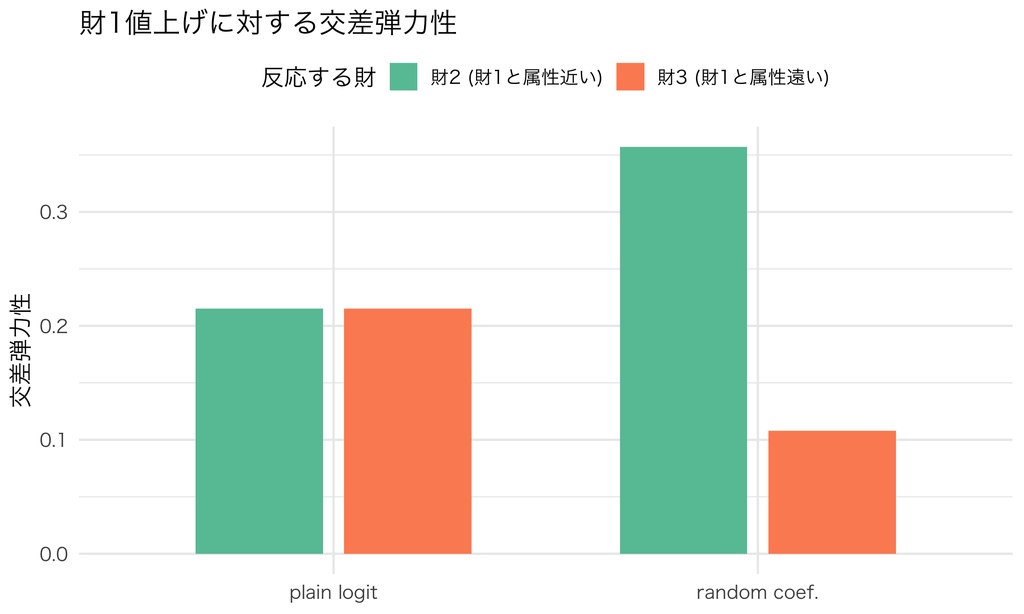

財1を値上げしたときの他財の反応。plain logit では財2・財3が同率、RC では属性の近い財2が強く反応する。

```r
df_plot <- data.frame(
  responder = rep(c("財2 (財1と属性近い)", "財3 (財1と属性遠い)"), 2),
  model     = rep(c("plain logit", "random coef."), each = 2),
  elasticity = c(E_homog[2, 1], E_homog[3, 1], E_heter[2, 1], E_heter[3, 1])
)
ggplot(df_plot, aes(model, elasticity, fill = responder)) +
  geom_col(position = position_dodge(width = 0.7), width = 0.6) +
  scale_fill_brewer(palette = "Set2") +
  labs(title = "財1値上げに対する交差弾力性",
       x = NULL, y = "交差弾力性", fill = "反応する財") +
  theme(legend.position = "top")
```

### 数式で確認

上の結果を、個人の選択確率から確かめよう。市場の添字 $t$ は省略し、タイプ $\boldsymbol{\nu}$ の消費者の財 $j$ の選択確率を $s_j(\boldsymbol{\nu})$、その人の価格係数を $\alpha(\boldsymbol{\nu})$ と書く。財 $k$ の価格だけを変えると、$j\ne k$ のとき、logitの公式から

$$\frac{\partial s_j(\boldsymbol{\nu})}{\partial p_k}
=\alpha(\boldsymbol{\nu})s_j(\boldsymbol{\nu})s_k(\boldsymbol{\nu})$$

となる。財 $k$ が値上がりすると、その消費者が財 $j$ を選ぶ確率は増える。ここでは価格が変わると平均効用 $\delta_k$ と個人偏差 $\mu_k$ の両方が変わり、合わせて効用は $-\alpha(\boldsymbol{\nu})$ だけ変化することに注意しよう。

**ノート個人の選択確率の微分**

$v_k(\boldsymbol{\nu})=\delta_k+\mu_k(\boldsymbol{\nu})$ と置く。$j\ne k$ のとき、logitの選択確率を $v_k$ で微分すると $\partial s_j(\boldsymbol{\nu})/\partial v_k=-s_j(\boldsymbol{\nu})s_k(\boldsymbol{\nu})$ である。また $\partial v_k/\partial p_k=-\alpha(\boldsymbol{\nu})$ なので、連鎖律を使えば

$$\frac{\partial s_j(\boldsymbol{\nu})}{\partial p_k}
=\frac{\partial s_j(\boldsymbol{\nu})}{\partial v_k}
\frac{\partial v_k}{\partial p_k}
=\alpha(\boldsymbol{\nu})s_j(\boldsymbol{\nu})s_k(\boldsymbol{\nu}).$$

個人の反応を人々について平均すれば、市場シェアの反応が得られる。交差価格弾力性は、その反応を財 $j$ のシェアに対する変化率に直したものなので、

$$\eta_{jk}
=\frac{p_k}{s_j}\frac{\partial s_j}{\partial p_k}
=\frac{p_k}{s_j}\int\alpha(\boldsymbol{\nu})
s_j(\boldsymbol{\nu})s_k(\boldsymbol{\nu})\,dF(\boldsymbol{\nu}),
\qquad j\ne k,$$

となる。ここで $s_j=\int s_j(\boldsymbol{\nu})\,dF(\boldsymbol{\nu})$ は市場シェアである。この式を $s_j(\boldsymbol{\nu})/s_j$ で重みを付けた平均と見ると、**財 $j$ を選びやすい人たちが、財 $k$ もどれくらい選びやすいか**が弾力性に関わることが分かる。その人たちの価格への反応 $\alpha(\boldsymbol{\nu})$ も弾力性に影響する。

通常のlogitでは、係数が全員共通なので、$s_j(\boldsymbol{\nu})=s_j$、$s_k(\boldsymbol{\nu})=s_k$、$\alpha(\boldsymbol{\nu})=\alpha$ である。このとき上の式は

$$\eta_{jk}=\alpha p_k s_k,\qquad j\ne k,$$

となり、反応する財 $j$ によらない。これが上の表で、同じ列の非対角成分が等しくなった理由である。

一方、random coefficient logitでは、人によって $s_j(\boldsymbol{\nu})$ と $s_k(\boldsymbol{\nu})$ が変わる。このシミュレーションでは、財1と財2は属性が近く、同じ属性を好む人たちが両方を選びやすい。そのため、財2を選びやすい人について見た財1の選択確率は、財3を選びやすい人について見るよりも高くなり、財1の値上げに対する財2の交差弾力性が財3より大きくなった。これはこの設定での結果であり、属性が近ければどんな場合でも必ず弾力性が大きい、という意味ではない。価格への反応の違いも含め、係数の分布や価格に応じて結果は変わる。

## 4. BLPによる需要の推定

ここまででrandom coefficient logitがどういうモデルなのかは理解できたはずだ。ただのlogitと比べてそんなに変わったところはなかった。シェアを計算するときに数値積分（モンテカルロ積分）をしなきゃいけなくなっただけである。が、この違いが推定というタスクにとっては実はとても大きな違いなのである。

前回やった通り、logit modelで価格の内生性に対処しようと思ったらBerry inversionが極めて重要な役割を果たしていた。 Berry inversionとは、シェアのベクトルを、mean utilityのベクトルへとひっくり返す作業であった。 思い出すためにここにplain loigtのinversionを再掲すると、

$$s_{jt}=\frac{e^{\delta_{jt}}}{1+\sum_{k=1}^Je^{\delta_{kt}}},\qquad
s_{0t}=\frac{1}{1+\sum_{k=1}^Je^{\delta_{kt}}}
\quad\Longrightarrow\quad
\delta_{jt}=\log s_{jt}-\log s_{0t}.$$

分母が共通なので、$s_{jt}/s_{0t}$ を取ると $e^{\delta_{jt}}$ だけが残る。 このように「逆転」できるのであった。

では同じことがrandom coefficient logitでできるだろうか？

個人タイプを $\boldsymbol{\nu}$ とし、その人のlogitの分母を

$$D_t(\boldsymbol{\nu};\delta)
=1+\sum_{k=1}^{J}\exp\{\delta_{kt}+\mu_{kt}(\boldsymbol{\nu})\}$$

と置く。すると、集計したシェアの比は

$$\frac{s_{jt}}{s_{0t}}
=e^{\delta_{jt}}
\frac{\displaystyle\int
e^{\mu_{jt}(\boldsymbol{\nu})}/D_t(\boldsymbol{\nu};\delta)\,dF(\boldsymbol{\nu})}
{\displaystyle\int 1/D_t(\boldsymbol{\nu};\delta)\,dF(\boldsymbol{\nu})}$$

になる。したがって $\log s_{jt}-\log s_{0t}$ は $\delta_{jt}$ に加えて、この積分の比の対数も含む。個人ごとには分母を消せても、**人々について平均したシェア同士の比では、積分の中の分母を消せない**。しかも、この余分な項は全商品の平均効用 $\delta_{\cdot t}$ に依存するので、観測シェアだけで計算して引くこともできない。異質性がなく $\mu=0$ なら積分の比は1になり、plain logitの式に戻る。

ということでBerry inversionはそのままでは使えない。

でもrandom coefficient logitに対してもBerry inversion的な手法がもしあって、mean utilityを取り出すことができたなら、それはすごい便利である。仮に、なんらかの「逆転」が存在して、mean utilityをシェアから引っ張り出すことができたとしよう。そしたら、あと残った推定の作業は

1. **OLSで平均係数と残差を求める。** 係数の分布を表すパラメータ $\theta_2$ を仮置きして反転した値を $\delta_{jt}(\theta_2)$ と書く。平均価格係数 $\alpha_0(\theta_2)$ も決まるので、$\delta_{jt}(\theta_2)+\alpha_0(\theta_2)p_{jt}$ を定数と外生的な属性に回帰すれば、平均係数 $\hat\beta(\theta_2)$ と残差 $\hat\xi_{jt}(\theta_2)$ が求まる。
2. **IVとのモーメントを計算する。** 妥当な操作変数 $Z_{jt}^D$ を用意し、$\hat\xi_{jt}(\theta_2)$ との積を観測全体で平均する。真のパラメータでは、母集団のモーメント $E[Z_{jt}^D\xi_{jt}]=0$ が成り立つことを利用する。
3. **モーメントをゼロに近づけるパラメータを探す。** $\theta_2$ の候補ごとに $\delta$ を取り出し直し、OLSも計算し直す。シェアが合うだけでは $\theta_2$ は決まらないので、追加のIVの条件を使って候補を比べる。

となる。これらのタスクは標準的な推定手法、GMMで実行することができる。

ということで問題は、**random coefficient loigtが作り出すシェアからmean utilityを取り出すためのinversionを見つけられるか**、ということになる。

### Berry, Levinsohn, and Pakes (1995)

**BLP（Berry, Levinsohn, and Pakes (1995)の略）**はこのrandom coefficient logitにおいて使えるinversionを開発した論文である。すごいのだが、残念ながらBLPの元の論文は読むのがめちゃくちゃむずく、発表されてすぐみんなが使い出すことはなかった。BLPのメソッドが使われ出すのは、Nevo (2000)などのいわゆるuser guide的な論文がきっかけだったと言われている。Nevoが人間の言葉に直してくれるまでBLPはほとんど理解できなかったし、理解できたとしても、コードに落とし込むのも容易ではなかったのである。

**ノート文献上の補足：Nevo (2000)の役割**

[Nevo (2000)](https://doi.org/10.1111/j.1430-9134.2000.00513.x)は、random coefficient logitの推定方法を説明し、理解と実装の難しさを減らすことを目的にした実務的なガイドである。ただし、「Nevo (2000)までBLPは使われなかった」という時系列は正確ではない。同論文自体が1990年代の応用研究を紹介している。上のくだりは原論文の読みにくさや実装の難しさについての評価と、ガイド論文の役割として読んでほしい。普及がNevoの論文から始まったと断定できるわけではない。

2026年現在、状況はかなり変わっている。Chris Conlonを中心とした[PyBLP](https://pyblp.readthedocs.io/en/stable/)がpython packageとしてBLPをかなり容易に使えるようにしてくれただけでなく、収束の遅さに対しても工夫を施すことで実行時間面でも改善された。ということで現代人としてBLPはそこまで恐るるに足らない。順序立てて追っていけばその中身を理解することができる。

PyBLPの[公式説明](https://pyblp.readthedocs.io/en/stable/introduction.html)では、Jeff GortmakerがChris Conlonと共同で開発したパッケージとされている。計算方法と実装上の改善は、[Conlon and Gortmaker (2020)](https://doi.org/10.1111/1756-2171.12352)にまとめられている。

ここからは、市場シェア・価格・商品属性のデータを使って、需要のパラメータをBLPで推定することでその流れを追っていく。価格係数だけに異質性を入れた小さな例で、BLPの計算を実装してみよう。ここでは、価格係数を $\alpha_i=\exp(a+\sigma\nu_i)$ と書く。後の合併分析にも、この推定結果をそのまま使う。

計算は、次の3つの段階に分かれる。

1. **シェア反転**：$(a,\sigma)$ を仮に決め、予測シェアが観測シェアに一致する平均効用 $\delta$ を求める。
2. **OLS**：$\delta+m(a,\sigma)p$ を定数と属性に回帰し、平均係数 $\hat\beta(a,\sigma)$ と残差 $\hat\xi(a,\sigma)$ を求める。
3. **IVによるGMM**：残差と追加の操作変数との標本モーメントがゼロに近くなるように、$(a,\sigma)$ を選ぶ。

step 1ではシェアを合わせ、step 2では仮置きしたパラメータの下で回帰を行う。どの $(a,\sigma)$ がデータと整合的かを選ぶために、step 3でIVの条件を使う。

### 4.1 同じ市場で推定と合併分析を行うためのデータ

まずはデータを作る。

財は3つ、市場は120個とする。各市場で、3社が1財ずつ販売している。消費者の効用は

$$u_{ijt}=\beta_0+\beta_x x_{jt}-\exp(a+\sigma\nu_i)p_{jt}
+\xi_{jt}+\varepsilon_{ijt}$$

である。

属性 $x$ と投入価格の対数 $w$ は、需要ショック $\xi$ と費用ショック $\omega$ から独立に発生させる。財 $j$ の限界費用は

$$mc_{jt}=\exp(\gamma_0+\gamma_xx_{jt}+\gamma_ww_{jt}+\omega_{jt})$$

とする。生産量にかかわらず限界費用は一定である。上の効用に基づく財 $j$ の市場シェアを $s_{jt}(p_{1t},p_{2t},p_{3t})$、市場の消費者数を $M_t$ とすると、企業 $j$ の利潤は

$$\pi_{jt}(p_{jt},p_{-j,t})
=M_t\,(p_{jt}-mc_{jt})s_{jt}(p_{jt},p_{-j,t})$$

である。ここで $p_{-j,t}$ は自社以外の2財の価格をまとめたものだ。各企業は、他社の価格を所与として、自社の価格を選ぶ：

$$\max_{p_{jt}\geq 0}\;\pi_{jt}(p_{jt},p_{-j,t})
\qquad (j=1,2,3)。$$

3社が同時に価格を選び、どの企業も自社の価格だけを変えて利潤を増やせない価格の組 $p_t^*$ を **Bertrand-Nash均衡**という。つまり、各 $j$ について $p_{jt}^*\in\arg\max_{p_{jt}\geq 0}\pi_{jt}(p_{jt},p_{-j,t}^*)$ が成り立つ。市場規模 $M_t>0$ は全ての利潤に同じように掛かるため、価格を選ぶ問題では省いてよい。

このシミュレーションでは内点解を考え、各社の利潤を自社価格で微分して得られる一階条件を同時に満たす価格を数値的に求める。これをデータ生成時の均衡価格として扱う。一階条件は内点最適化の必要条件であり、それだけで大域的な最適性が自動的に保証されるわけではない。価格設定の条件は、後の合併分析で詳しく見る。

ここで費用関数を使うのは、観測される価格とシェアを生成するためである。**この節の推定には、需要側のモーメントだけを使う。** 分析者が見るのは $x,w,p,s$ と所有関係であり、生成に使った $\xi,\omega,mc$ は見えないものとして扱う。

**ノート需要と価格を計算する関数**

前のシミュレーションでは個人を乱数で発生させたが、ここでは標準正規分布の分位点を120個並べて積分を近似する。反復のたびに個人を引き直すと目的関数自体が変わってしまうので、どのパラメータ候補でも同じ点を使う。価格の反復計算には、更新を半分ずつ進める方法を使い、収束しなかった場合には停止するようにしている。

```r
# 個人の価格係数は正。nu はどの計算でも同じ積分点を使う。
rc_probs <- function(p, quality, a, sigma, nu) {
  alpha <- exp(a + sigma * nu)
  v <- sweep(-outer(alpha, p), 2, quality, "+")
  vmax <- pmax(0, apply(v, 1, max))
  ev <- exp(v - vmax)
  ev / (exp(-vmax) + rowSums(ev))
}
rc_market <- function(p, quality, a, sigma, nu) {
  prob <- rc_probs(p, quality, a, sigma, nu)
  alpha <- exp(a + sigma * nu)
  jac <- crossprod(prob, prob * alpha) / length(nu)
  diag(jac) <- diag(jac) - colMeans(prob * alpha)
  list(s = colMeans(prob), jac = jac)
}
owner_matrix <- function(groups) outer(groups, groups, "==") * 1
markup_at <- function(p, groups, quality, a, sigma, nu) {
  demand <- rc_market(p, quality, a, sigma, nu)
  Delta <- -owner_matrix(groups) * t(demand$jac)
  as.vector(solve(Delta, demand$s))
}
solve_prices <- function(mc, groups, quality, a, sigma, nu,
                         p_init = mc + 1, tol = 1e-10, maxit = 2000) {
  p <- p_init
  for (it in seq_len(maxit)) {
    target <- mc + markup_at(p, groups, quality, a, sigma, nu)
    err <- max(abs(target - p))
    if (err < tol) return(list(p = p, iterations = it, error = err))
    p <- 0.5 * p + 0.5 * target
  }
  stop("価格の反復が収束しなかった")
}
# 複数市場の確率をまとめて計算。各積分点について市場を並べ、列は商品。
rc_all <- function(delta, price, a, sigma, nu, slopes = TRUE) {
  nt <- nrow(price); nj <- ncol(price); nr <- length(nu)
  mean_alpha <- exp(a + sigma^2 / 2)
  deviation <- exp(a + sigma * nu) - mean_alpha
  v <- matrix(0, nt * nr, nj)
  for (j in seq_len(nj)) {
    v[, j] <- rep(delta[, j], nr) -
      rep(price[, j], nr) * rep(deviation, each = nt)
  }
  vmax <- pmax(0, v[, 1])
  for (j in 2:nj) vmax <- pmax(vmax, v[, j])
  ev <- exp(v - vmax)
  prob <- ev / (exp(-vmax) + rowSums(ev))
  share <- matrix(0, nt, nj)
  own_slope <- matrix(0, nt, nj)
  alpha <- rep(exp(a + sigma * nu), each = nt)
  for (j in seq_len(nj)) {
    share[, j] <- rowMeans(matrix(prob[, j], nt, nr))
    if (slopes) own_slope[, j] <- -rowMeans(matrix(
      alpha * prob[, j] * (1 - prob[, j]), nt, nr))
  }
  list(share = share, own_slope = own_slope)
}
invert_shares <- function(S_obs, price, a, sigma, nu,
                          tol = 1e-9, maxit = 2000) {
  delta <- log(S_obs) - log(1 - rowSums(S_obs))
  for (it in seq_len(maxit)) {
    predicted <- rc_all(delta, price, a, sigma, nu, slopes = FALSE)$share
    correction <- log(S_obs) - log(predicted)
    delta <- delta + correction
    if (max(abs(correction)) < tol) {
      return(list(delta = delta, iterations = it,
                  error = max(abs(correction))))
    }
  }
  stop("シェアの反転が収束しなかった")
}
vec <- function(m) as.vector(t(m))
# その市場の需要を固定したときの1人あたり消費者余剰。
cs_value <- function(p, quality, a, sigma, nu) {
  alpha <- exp(a + sigma * nu)
  v <- sweep(-outer(alpha, p), 2, quality, "+")
  vmax <- pmax(0, apply(v, 1, max))
  inclusive <- vmax + log(exp(-vmax) + rowSums(exp(v - vmax)))
  mean(inclusive / alpha)
}
market_outcomes <- function(p, mc, quality, a, sigma, nu, market_size = 10000) {
  s <- rc_market(p, quality, a, sigma, nu)$s
  c(quantity = market_size * sum(s),
    profit = market_size * sum((p - mc) * s),
    consumer_surplus = market_size * cs_value(p, quality, a, sigma, nu))
}
```

```r
set.seed(202604)
J <- 3
Tn <- 120
ns <- 120
# 等間隔の確率に対応する標準正規分布の分位点。毎回引き直さない。
nu <- qnorm((seq_len(ns) - 0.5) / ns)
theta_true <- c(beta0 = 3.5, beta_x = 1.2, a = 0.2, sigma = 0.7,
                gamma0 = -0.1, gamma_x = 0.15, gamma_w = 0.6)
x <- matrix(runif(Tn * J, -1, 1), Tn, J)
w <- matrix(runif(Tn * J, -1.2, 1.2), Tn, J)
xi_true <- matrix(rnorm(Tn * J, 0, 0.18), Tn, J)
omega_true <- matrix(rnorm(Tn * J, 0, 0.08), Tn, J)
quality_true <- theta_true["beta0"] + theta_true["beta_x"] * x + xi_true
mc_true <- exp(theta_true["gamma0"] + theta_true["gamma_x"] * x +
                 theta_true["gamma_w"] * w + omega_true)
groups_pre <- seq_len(J)
price <- S_obs <- matrix(0, Tn, J)
for (tt in seq_len(Tn)) {
  eq <- solve_prices(mc_true[tt, ], groups_pre, quality_true[tt, ],
                     theta_true["a"], theta_true["sigma"], nu)
  price[tt, ] <- eq$p
  S_obs[tt, ] <- rc_market(eq$p, quality_true[tt, ],
                          theta_true["a"], theta_true["sigma"], nu)$s
}
```

需要ショックが高い商品では企業が高い価格を付けやすくなる。費用が外生的に動く部分もあるが、価格全体が外生になるわけではない。第3回で扱った価格の内生性が、企業の価格設定を通じて生じるデータになっている。

```r
data_summary <- data.frame(
  variable = c("価格", "商品シェア", "外部選択肢シェア"),
  minimum = c(min(price), min(S_obs), min(1 - rowSums(S_obs))),
  maximum = c(max(price), max(S_obs), max(1 - rowSums(S_obs))))
knitr::kable(data_summary, digits = 3,
             col.names = c("変数", "最小値", "最大値"))
```

| 変数 | 最小値 | 最大値 |
| --- | --- | --- |
| 価格 | 1.314 | 3.824 |
| 商品シェア | 0.044 | 0.464 |
| 外部選択肢シェア | 0.149 | 0.487 |

### 4.2 step 1： 反復計算で平均効用を取り出す

この例の平均価格係数を $m(a,\sigma)=E[\alpha_i]=\exp(a+\sigma^2/2)$ と書く。ここでの $a$ は、先ほどの $\bar\alpha$ に当たる、価格係数の対数の平均である。平均効用と個人偏差を

$$\delta_{jt}=\beta_0+\beta_x x_{jt}-m(a,\sigma)p_{jt}+\xi_{jt},
\qquad
\mu_{ijt}=-\{\exp(a+\sigma\nu_i)-m(a,\sigma)\}p_{jt}$$

と分けて書く。

$(a,\sigma)$ を固定して、$\delta_{jt}$ に対して次の**更新式**を考える。つまり、この式の右辺に今手元にあるパラメータの値や$\delta$の値を入れて、左辺に出てきた値を「新しい$\delta_{jt}$」として手元の$\delta_{jt}$を更新する、ということをする。

$$\delta_{jt}^{\mathrm{new}}
=\delta_{jt}+\log s_{jt}^{\mathrm{obs}}
-\log s_{jt}(\delta;a,\sigma).$$

この更新式のメカニズムは至ってシンプルである。$\delta$の更新幅に書き直すと、
$$\delta_{jt}^{\mathrm{new}} - \delta_{jt}
=\log s_{jt}^{\mathrm{obs}}
-\log s_{jt}(\delta;a,\sigma).$$

なので、**予測したシェアが小さすぎる財では平均効用を上げ、大きすぎる財では下げる**、という更新に過ぎない。 そして最終目的がシェアの予測が実測に近くなる$\delta_{jt}$を求めることならば、この更新は極めて自然である。実際、予測するシェアと実測のシェアが一致したら、$\delta$の更新はばは$0$になり、更新は止まる、ということはこの式から一目瞭然である。

実装上は、初期値だけこちらから与える必要がある。なんでもいいのだが、例えば前回のBerry反転 $\log s_{jt}-\log s_{0t}$ を初期値にして、更新幅が十分小さくなるまで繰り返す、という形でこのstep 1は実装されることが多い。

実際にやってみると、

```r
truth_inversion <- invert_shares(S_obs, price,
  theta_true["a"], theta_true["sigma"], nu)
delta_true <- quality_true - exp(theta_true["a"] + theta_true["sigma"]^2 / 2) * price
inversion_check <- data.frame(
  check = c("平均効用の回収誤差", "シェアの再現誤差"),
  error = c(max(abs(truth_inversion$delta - delta_true)),
    max(abs(rc_all(truth_inversion$delta, price,
      theta_true["a"], theta_true["sigma"], nu)$share - S_obs))))
knitr::kable(inversion_check, digits = 10,
             col.names = c("確認項目", "最大絶対誤差"))
```

| 確認項目 | 最大絶対誤差 |
| --- | --- |
| 平均効用の回収誤差 | 0.0000000118 |
| シェアの再現誤差 | 0.0000000003 |

```r
stopifnot(all(inversion_check$error < 1e-6))
```

真のパラメータを与えたときに、元の平均効用を取り戻せることを確認できる。

**ノートこの更新は必ず止まるのか？**

シェアが合えば更新が止まる、という説明だけでは、その点に近づける保証にはならない。ここで役に立つのが **contraction mapping（縮小写像）** という考え方である。二つの候補に同じ更新を施すと、更新後の距離が更新前より小さくなるような写像をいう。更新を $T$ と書き、距離を「成分ごとの差の絶対値の最大値」$\|d\|_\infty=\max_j|d_j|$ で測れば、ある一定の $0\leq\rho<1$ に対して

$$\|T(\delta)-T(\widetilde\delta)\|_\infty
\leq\rho\|\delta-\widetilde\delta\|_\infty$$

が成り立つ、という性質である。更新がその領域の中にとどまり、この不等式が成り立つなら、反復するほど候補間の距離は小さくなり、一つの固定点に近づく。

今回の更新がこの性質を持つ理由も確かめておこう。市場 $t$ と $(a,\sigma)$ を固定し、添字 $t$ を省く。$s_{ij}$ を現在の $\delta$ で計算した個人の選択確率とすると、

$$T_j(\delta)=\delta_j+\log s_j^{\mathrm{obs}}-\log s_j(\delta),
\qquad
\frac{\partial T_j}{\partial\delta_k}
=\frac{E_\nu[s_{ij}s_{ik}]}{s_j}\quad (j,k=1,\ldots,J).$$

微分がすべて非負で、その行方向の和は

$$\sum_{k=1}^J\frac{\partial T_j}{\partial\delta_k}
=\frac{E_\nu[s_{ij}(1-s_{i0})]}{s_j}
=1-\frac{E_\nu[s_{ij}s_{i0}]}{s_j}<1$$

となる。買わない確率 $s_{i0}$ が正なので、候補の違いが更新後にそのまま増幅されることはない。連続なこの微分を有界な閉領域で考えれば、行和の最大値を $1$ より小さい一定の $\rho$ で押さえられる。**ただし、$\delta$ を無制限に動かせる領域全体で、同じ $\rho<1$ が使えるとは限らない。** [BLP (1995), Appendix I](https://www.its.caltech.edu/~mshum/gradio/papers/BerryLevinsohnPakes1995.pdf)では、正の観測シェアとoutside shareなどの条件のもと、適切な上限を設けた写像を用いて固定点の一意性と収束を示している。

次の図では、市場1について初期値を三通り変え、3商品の平均効用を同時に更新する。破線は、このシミュレーションで分かっている固定点である。

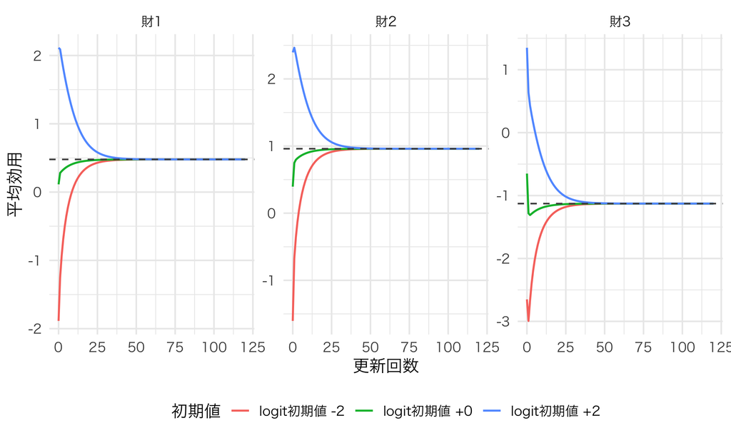

三通りの初期値から平均効用を同時更新する。各商品の値は同じ固定点（破線）へ近づく。

```r
trace_market <- 1
trace_price <- price[trace_market, , drop = FALSE]
trace_share <- S_obs[trace_market, , drop = FALSE]
trace_base <- log(trace_share) - log(1 - sum(trace_share))
trace_steps <- 120
trace_offsets <- c(-2, 0, 2)
trace_paths <- lapply(seq_along(trace_offsets), function(h) {
  d <- trace_base + trace_offsets[h]
  path <- matrix(NA_real_, trace_steps + 1, J)
  path[1, ] <- d
  for (n in seq_len(trace_steps)) {
    predicted <- rc_all(d, trace_price, theta_true["a"],
      theta_true["sigma"], nu, slopes = FALSE)$share
    d <- d + log(trace_share) - log(predicted)
    path[n + 1, ] <- d
  }
  data.frame(iteration = rep(0:trace_steps, J),
    product = rep(paste0("財", seq_len(J)), each = trace_steps + 1),
    delta = as.vector(path),
    initial = paste0("logit初期値 ", sprintf("%+g", trace_offsets[h])))
})
trace_df <- do.call(rbind, trace_paths)
trace_target <- data.frame(product = paste0("財", seq_len(J)),
  target = as.vector(delta_true[trace_market, ]))
ggplot(trace_df, aes(iteration, delta, color = initial)) +
  geom_line(linewidth = 0.75) +
  geom_hline(data = trace_target, aes(yintercept = target),
    inherit.aes = FALSE, linetype = "dashed", color = "grey30") +
  facet_wrap(~product, nrow = 1, scales = "free_y") +
  labs(x = "更新回数", y = "平均効用", color = "初期値") +
  theme(legend.position = "bottom")
```

図はこの例での収束を示すものであり、一般的な収束の証明は上の性質による。また、理論上の収束は通常、無限回の更新に関する話である。実装では更新幅が許容誤差より小さくなった時点で止める。outside shareが小さく、上の行和が $1$ に近いと収束は遅くなる。ゼロの観測シェアには対数を使えず、反復上限までに収束しないこともあるため、コードでは許容誤差と反復上限を設け、失敗を検出している。

このようにして取り出した$\delta$を$\delta_{jt}(\alpha, \sigma)$とかく。

ここで価格係数の分布を指定するパラメータは、対数価格係数の平均 $a$ と標準偏差 $\sigma$ である。以下では、この依存関係を $\delta_{jt}(a,\sigma)$ と表記する。

ただし、**シェアを再現できただけでは、異質性を推定したことにはならない**。別の $(a,\sigma)$ を与えても、それに合わせて $\delta$ を調整できてしまうからだ。そこで、まずOLSで残差を取り出し、続くstep 3でその残差と操作変数の関係を使う。

### 4.3 step 2： OLSで平均係数と残差を求める

$(a,\sigma)$ を仮に決めると、平均価格係数 $m(a,\sigma)$ も決まる。まず、真のパラメータの下で成り立つ平均効用の式を確認すると、

$$\delta_{jt}(a,\sigma)
=\beta_0+\beta_x x_{jt} - m(a,\sigma)p_{jt} +\xi_{jt}$$

である。左辺はstep 1で取り出せ、右辺の $x_{jt},p_{jt}$ は観測できる。候補の $(a,\sigma)$ が真値かどうかはまだ分からないが、それぞれの候補で $\delta_{jt}(a,\sigma)$ と $m(a,\sigma)$ は計算できるので、これらを使って平均係数と残差を求めよう。

価格の項を左辺に移すと、

$$\underbrace{\delta_{jt}(a,\sigma)+m(a,\sigma)p_{jt}}_{y_{jt}(a,\sigma)}
=\beta_0+\beta_x x_{jt}+\xi_{jt}$$

となる。**$(a,\sigma)$ を固定した今、この左辺を定数と $x_{jt}$ にOLSで回帰すればよい。** 今回のデータでは、属性 $x_{jt}$ は需要ショックから独立に生成している。価格係数の分布は仮に固定して価格の項を左辺へ移しているため、回帰の右辺に残る説明変数は外生的な属性だけである。

具体的には、計量経済学Iで学んだ残差二乗和の最小化によって、

$$\hat\beta(a,\sigma)
=\begin{pmatrix}\hat\beta_0(a,\sigma)\\\hat\beta_x(a,\sigma)\end{pmatrix}
=\arg\min_{\beta_0,\beta_x}
\sum_{j,t}\{y_{jt}(a,\sigma)-\beta_0-\beta_xx_{jt}\}^2$$

を求める。その残差は

$$\hat\xi_{jt}(a,\sigma)
=y_{jt}(a,\sigma)-\hat\beta_0(a,\sigma)-\hat\beta_x(a,\sigma)x_{jt}$$

である。ここで得られるのは、**その候補 $(a,\sigma)$ の下での平均係数と残差**である。候補を変えれば左辺も変わるので、OLSも計算し直す。仮置きした値が真値と違えば、この残差が元の需要ショックを正しく取り出しているとは限らない。

```r
X_d <- cbind(constant = 1, x = vec(x))
N <- nrow(X_d)
# 固定した価格係数の分布の下で、平均係数と残差をOLSで求める。
linear_ols <- function(y, X) {
  fit <- lm.fit(x = X, y = y)
  list(coef = as.vector(fit$coefficients),
       residual = as.vector(fit$residuals))
}
```

`vec()` は、市場1の財1・2・3、市場2の財1・2・3、という順に行列を並べ直す関数である。説明変数とシェアから取り出した平均効用の順序をそろえないと、別の市場の商品どうしを対応させることになる。行列計算ではこの点に注意しよう。

属性の係数も $\beta_{xi}=\bar\beta_x+\Sigma^{1/2}\nu_i$ のようにランダムにする場合も、$\Sigma$ を外側で仮に固定すれば同じ考え方を使える。その場合、OLSで求めるのは属性への評価の平均 $\bar\beta_x$ であり、ばらつきを表す $\Sigma$ もstep 3で選ぶ対象になる。

### 4.4 step 3： IVの条件で価格係数の分布を選ぶ

ここまでで、$(a,\sigma)$を固定したら他のパラメータは推定できることがわかった。

では、$(a,\sigma)$ はどう選べばよいだろうか。step 1では候補ごとに $\delta$ を調整してシェアを再現できた。step 2のOLSも、それぞれの候補について計算できる。しかもOLSの性質から、どの候補でも

$$\sum_{j,t}\hat\xi_{jt}(a,\sigma)=0,
\qquad
\sum_{j,t}x_{jt}\hat\xi_{jt}(a,\sigma)=0$$

が成り立つ。つまり、残差が定数や自財の属性と直交するという条件だけでは、候補を区別できない。

**ここで、追加のIVを導入する。** 費用を動かす変数や競合商品の属性など、需要ショックとは無相関だが価格や競争環境を動かす変数を使う。真のパラメータでは需要ショックとこれらのIVは無相関になるはずだが、誤った候補から取り出した残差は、その条件を満たすとは限らない。この違いを使って $(a,\sigma)$ を選ぶ。もちろん、IVが妥当であることに加えて、候補を区別できるだけの変動が必要である。

IVの本数を $K_D$ とする。各商品・市場について $Z^D_{jt}=(Z^D_{jt,1},\ldots,Z^D_{jt,K_D})'$ は $K_D\times1$ の列ベクトルであり、一つの商品・市場の需要残差 $\xi_{jt}$ はスカラーである。したがって、両者の積を平均した $\bar g_D$ も $K_D\times1$ の列ベクトルになる。下のコードでは $K_D=6$、$N=3\times120=360$ である。 すなわち、なんらかのIVを$Z_{jt}^D$とかき、$N=JT$ として

$$\bar g_D(a,\sigma,\beta)=\frac{1}{N}\sum_{j,t}Z^D_{jt}
\{\delta_{jt}(a,\sigma)+m(a,\sigma)p_{jt}-\beta_0-\beta_xx_{jt}\}$$

とする。各候補 $(a,\sigma)$ について、$\beta$ にはstep 2のOLSで求めた $\hat\beta(a,\sigma)$ を代入する。その上で、このベクトルをなるべく小さくするような $(a,\sigma)$ を探す。

この手続きは一般にGMM（generalized method of moments）と呼ばれる推定手法である。計量経済学IでGMMを導入したか覚えてないのでここで最もシンプルなGMMもどきを導入して説明する。

まず、IVの一つ一つをindex $k$で表すとすると、先ほどの$\bar g_D$を「ベクトル」で書くと以下のようにかける。
$$\bar g_D(a,\sigma,\beta)
=\begin{pmatrix}
\dfrac{1}{N}\displaystyle\sum_{j,t}Z^D_{jt,1}
\{\delta_{jt}(a,\sigma)+m(a,\sigma)p_{jt}-\beta_0-\beta_xx_{jt}\}\\[6pt]
\dfrac{1}{N}\displaystyle\sum_{j,t}Z^D_{jt,2}
\{\delta_{jt}(a,\sigma)+m(a,\sigma)p_{jt}-\beta_0-\beta_xx_{jt}\}\\[6pt]
\vdots\\[3pt]
\dfrac{1}{N}\displaystyle\sum_{j,t}Z^D_{jt,K_D}
\{\delta_{jt}(a,\sigma)+m(a,\sigma)p_{jt}-\beta_0-\beta_xx_{jt}\}
\end{pmatrix}.$$

各行が「ある一つのIVと需要残差を掛けて、商品・市場について平均したもの」に当たる。

IVが望ましい性質を満たしているとき、真のパラメータの元では、このベクトルの各要素は$0$に近しいはずである。なぜなら、$\xi_{jt} = \delta_{jt}(a,\sigma)+m(a,\sigma)p_{jt}-\beta_0-\beta_xx_{jt}$とIVは無相関、というのが「IVの望ましい性質」だからである。（そしてこのベクトルの各要素はその「相関」の推定値になっている）

ということで、このベクトルの全要素がなるべく$0$になるようなパラメータを計算したい。 そのための具体的な手続きとして、**ベクトルの各要素の二乗和を最小化する**という手続きを考えよう。二乗和が$0$に近かったら、各要素は必然的に$0$に近いはずなので、この手続きは筋良しな気がする。

というのがGMM（もどき）である。以下ではこの「ベクトルの二乗和」のことを$Q_D$とかく。

単純な二乗和なら $Q_D=\bar g_D'\bar g_D$ である。実際のコードでは、IVの単位や大きさによって特定の要素だけが過度に重視されないよう、**重みを付けた二乗和**

$$Q_D(a,\sigma)=\bar g_D'W_D\bar g_D,
\qquad
W_D=\left(\frac{Z_D'Z_D}{N}\right)^{-1}$$

を使う。$Z_D$ は各行を $(Z^D_{jt})'$ とした $N\times K_D$ の行列で、$W_D$ は $K_D\times K_D$ の行列である。$C'C=W_D$ を満たす行列 $C$ を使えば、$Q_D=\|C\bar g_D\|^2$ と書ける。つまり、尺度をそろえたモーメントの二乗和を最小化しており、$W_D=I$ とすれば先ほどの単純な二乗和に戻る。以下は、この重みを固定した一段階GMMである。

```r
# 自財の費用変数と競合財の属性・費用変数を需要側のIVに使う。
rival_x <- rowSums(x) - x
rival_w <- rowSums(w) - w
Z_d <- cbind(X_d, w = vec(w), w2 = vec(w)^2,
              rival_x = vec(rival_x), rival_w = vec(rival_w))
W_d <- solve(crossprod(Z_d) / N)
scale_d <- 1
```

ここで新しく考えたいのが、**他の商品の属性から作るBLP型のIV**である。商品 $j$ を販売する企業を $f(j)$、企業 $f$ の商品集合を $\mathcal J_{ft}$ とすると、典型的には

$$z_{jt}^{\mathrm{same}}
=\sum_{k\in\mathcal J_{f(j)t},\ k\ne j}x_{kt},
\qquad
z_{jt}^{\mathrm{rival}}
=\sum_{k\notin\mathcal J_{f(j)t}}x_{kt}$$

という、同一企業の他商品の属性和と、競合企業の商品の属性和を使う。[PyBLPの公式説明](https://pyblp.readthedocs.io/en/stable/_api/pyblp.build_blp_instruments.html)も、この二種類を区別している。今回のデータでは各企業が1財だけを持つので、前者は常にゼロで情報を持たない。後者がコードの `rival_x = rowSums(x) - x` に対応する。例えば財1については、財2と財3の属性を足したものである。

なぜIVの候補になるのだろうか。需要残差を取り出した式は

$$\delta_{jt}+m(a,\sigma)p_{jt}=\beta_0+\beta_xx_{jt}+\xi_{jt}$$

であり、自財の効用には他財の属性が直接入っていない。一方で、競合商品の属性が変われば消費者の選択確率と自財への需要が変わるため、企業が選ぶ価格 $p_{jt}$ は変わり得る。**自財の効用に直接入らず、競争を通じて価格を動かす**という役割である。これは、他財の属性が自財のシェアに影響しない、という意味ではない。シェアには選択肢間の比較を通じて影響する。

ただし、この役割だけでは外生性は保証されない。市場内の全商品の属性を $X_t=(x_{1t},\ldots,x_{Jt})$、所有関係を $\mathcal O_t$ とし、例えば

$$E[\xi_{jt}\mid X_t,\mathcal O_t]=0$$

を仮定する。このとき、$z_{jt}^{\mathrm{rival}}$ は $X_t,\mathcal O_t$ の関数なので、繰り返し期待値を使うと

$$E[z_{jt}^{\mathrm{rival}}\xi_{jt}]
=E\!\left[z_{jt}^{\mathrm{rival}}
E[\xi_{jt}\mid X_t,\mathcal O_t]\right]=0$$

と確認できる。自財の属性と需要ショックが無相関という条件だけでは足りず、**他財の属性にも同じ需要ショックの情報が含まれない**という強い仮定が必要なのである。今回のシミュレーションでは、全商品の $x$ と全商品の $\xi$ を独立に生成し、所有関係も固定しているので、この条件が成立する。実際の市場で企業が未観測の人気を予測して品揃えや品質を決めるなら、同じ条件が成立するとは限らない。また、価格を十分に動かす関連性と、パラメータを区別するだけの情報があるかも、外生性とは別に確認が必要である。

コードとの対応も記しておくと、使用する6本は $Z^D_{jt}=(1,x_{jt},w_{jt},w_{jt}^2,\sum_{k\ne j}x_{kt},\sum_{k\ne j}w_{kt})'$ である。上で説明したBLP型IVは5番目に当たり、計算ではこれに自財の属性と、前回も扱った費用側のIVを組み合わせている。これらの費用変数も、今回のデータ生成では全商品の需要ショックから独立である。

**ノート補足：標準的なBLPの計算との関係**

BLPの計算は、内側のループでシェアを反転し、外側のループで非線形パラメータを選ぶ、と説明されることが多い。このノートでは、その途中で線形係数を求める処理も独立したstepとして示した。OLSは $(a,\sigma)$ の候補ごとに計算するため、内側・外側という計算構造は同じである。[PyBLPの説明](https://pyblp.readthedocs.io/en/stable/background.html#the-objective)にも、シェア反転の後に線形係数を求め、残差とIVから目的関数を計算する手順が示されている。

今回のOLSは、この重みを使った線形GMMの解と一致する。$X$ を定数と属性の行列、$y=y(a,\sigma)$ とすると、$Z_D$ は $X$ の列をすべて含むので、$P_Z=Z_D(Z_D'Z_D)^{-1}Z_D'$ に対して $P_ZX=X$ である。したがって、必要な行列が正則なら

$$\hat\beta_{\mathrm{GMM}}
=(X'P_ZX)^{-1}X'P_Zy
=(X'X)^{-1}X'y
=\hat\beta_{\mathrm{OLS}}.$$

一般の重み行列ではこの一致は保証されない。また、平均価格係数も線形係数として推定し、価格を回帰の右辺に残す設定では、価格が内生的なので、その線形係数を求める段階にもIVを使う。ここでは価格係数の分布を外側で固定し、残る線形説明変数を外生的な属性だけにしていることがポイントである。

最後に、$(a,\sigma)$ を動かしながら、シェア反転とOLSを繰り返す。各候補で $\hat\xi(a,\sigma)$ とIVのモーメントを計算し、$Q_D(a,\sigma)$ が最も小さくなる場所を探す。

以下では `optim()` を使い、2つの初期値から計算する。探索する範囲は $-0.4\leq a\leq1$、$0.05\leq\sigma\leq1.3$ とする。これは今回の計算用の範囲であり、一般にこの範囲でよいわけではない。推定値が端に張り付いた場合には、範囲や仕様を見直す必要がある。

```r
gmm_fit <- function(par) {
  a <- par[1]; sigma <- par[2]
  inverted <- invert_shares(S_obs, price, a, sigma, nu)
  delta <- inverted$delta
  mean_alpha <- exp(a + sigma^2 / 2)
  # step 2: delta + E[alpha]*p を定数と属性にOLSで回帰する。
  demand <- linear_ols(vec(delta + mean_alpha * price), X_d)
  # step 3: OLS残差とIVのモーメントで、この候補を評価する。
  g <- crossprod(Z_d, demand$residual) / N
  Qd <- as.numeric(t(g) %*% W_d %*% g)
  fit <- list(par = setNames(par, c("a", "sigma")), beta = demand$coef,
              delta = delta, xi = demand$residual, Qd = Qd,
              Q = Qd / scale_d, inversion_error = inverted$error)
  fit
}
# 開始点を複数試し、目的関数が最も小さい結果を使う。
estimate_model <- function() {
  starts <- list(c(0.1, 0.4), c(0.4, 0.9))
  runs <- lapply(starts, function(initial) {
    optim(initial, function(par) gmm_fit(par)$Q,
          method = "L-BFGS-B", lower = c(-0.4, 0.05), upper = c(1, 1.3),
          control = list(factr = 1e7, pgtol = 1e-7))
  })
  best <- runs[[which.min(sapply(runs, function(z) z$value))]]
  result <- gmm_fit(best$par)
  result$convergence <- best$convergence
  result
}
fit_d <- estimate_model()
```

```r
point_estimates <- data.frame(
  parameter = c("beta0", "beta_x", "a", "sigma", "mean_alpha"),
  truth = c(theta_true[c("beta0", "beta_x", "a", "sigma")],
    exp(theta_true["a"] + theta_true["sigma"]^2 / 2)),
  estimated = c(fit_d$beta, fit_d$par, exp(fit_d$par[1] + fit_d$par[2]^2 / 2)))
knitr::kable(point_estimates, digits = 3,
             col.names = c("パラメータ", "真値", "推定値"))
```

| パラメータ | 真値 | 推定値 |
| --- | --- | --- |
| beta0 | 3.50 | 3.439 |
| beta_x | 1.20 | 1.168 |
| a | 0.20 | 0.191 |
| sigma | 0.70 | 0.677 |
| mean_alpha | 1.56 | 1.522 |

```r
stopifnot(fit_d$convergence == 0)
```

生成に使った真値と推定値を比べてみよう。標本は有限なので、推定値が真値とぴったり一致するわけではないが、大体いい感じでは？

目的関数の形も見てみよう。次の図では $a$ を推定値に固定し、各 $\sigma$ で $\delta$ と $\beta$ を求め直している。2つのパラメータを同時に最適化した後の、一方向の断面である。ちゃんと真の値付近で$Q_D$が小さくなっている。素晴らしい。

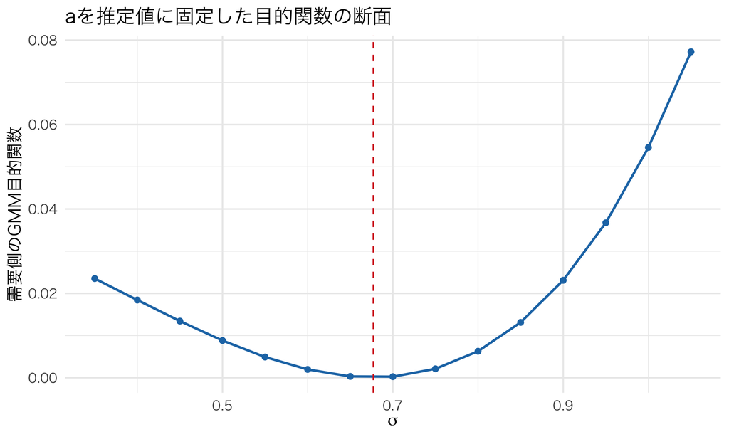

破線は推定したσ。各点でシェア反転とOLSを行い、残差とIVのモーメントを評価している。

```r
sigma_grid <- seq(0.35, 1.05, length.out = 15)
objective_slice <- data.frame(sigma = sigma_grid,
  Q = sapply(sigma_grid, function(s) gmm_fit(c(fit_d$par[1], s))$Q))
ggplot(objective_slice, aes(sigma, Q)) +
  geom_line(color = "#1f77b4", linewidth = 0.9) +
  geom_point(color = "#1f77b4") +
  geom_vline(xintercept = fit_d$par[2], color = "#d62728", linetype = "dashed") +
  labs(x = expression(sigma), y = "需要側のGMM目的関数",
       title = "aを推定値に固定した目的関数の断面")
```

**ノート推定値の不確実性**

推定値だけでなく、標準誤差も確認しておこう。市場ごとに同じ企業や競合関係を共有するため、ここでは市場内の残差の相関を許す、市場単位のクラスタ標準誤差を計算する。独立な市場が十分に多いという近似に基づく。GMMのモーメントがパラメータを動かしたときにどれくらい変わるかと、市場間でどれくらいばらつくかを組み合わせる計算である。

```r
cluster_se <- function(fit) {
  qd <- ncol(Z_d)
  G <- matrix(0, qd, 4)
  G[, 1:2] <- -crossprod(Z_d, X_d) / N
  h <- 1e-4
  for (k in 1:2) {
    upper <- lower <- fit$par
    upper[k] <- upper[k] + h; lower[k] <- lower[k] - h
    fit_upper <- gmm_fit(upper); fit_lower <- gmm_fit(lower)
    y_upper <- fit_upper$delta + exp(upper[1] + upper[2]^2 / 2) * price
    y_lower <- fit_lower$delta + exp(lower[1] + lower[2]^2 / 2) * price
    G[, k + 2] <- crossprod(Z_d, vec(y_upper - y_lower)) / (2 * h * N)
  }
  moments <- Z_d * fit$xi
  clustered <- rowsum(moments, rep(seq_len(Tn), each = J))
  clustered <- sweep(clustered, 2, colMeans(clustered), "-")
  Vg <- crossprod(clustered) / N^2 * Tn / (Tn - 1)
  bread <- solve(t(G) %*% W_d %*% G)
  V <- bread %*% t(G) %*% W_d %*% Vg %*% W_d %*% G %*% bread
  list(se = sqrt(diag(V)), vcov = V)
}
inference_d <- cluster_se(fit_d)
mean_alpha_d <- exp(fit_d$par[1] + fit_d$par[2]^2 / 2)
gradient_mean <- c(0, 0, mean_alpha_d, mean_alpha_d * fit_d$par[2])
se_mean_alpha <- sqrt(as.numeric(t(gradient_mean) %*% inference_d$vcov %*% gradient_mean))
demand_parameters <- data.frame(
  parameter = c("beta0", "beta_x", "a", "sigma", "mean_alpha"),
  truth = c(theta_true[c("beta0", "beta_x", "a", "sigma")],
              exp(theta_true["a"] + theta_true["sigma"]^2 / 2)),
  estimated = c(fit_d$beta, fit_d$par, mean_alpha_d),
  std_error = c(inference_d$se, se_mean_alpha))
knitr::kable(demand_parameters, digits = 3,
             col.names = c("パラメータ", "真値", "推定値", "標準誤差"),
             caption = "需要パラメータと市場クラスタ標準誤差")
```

需要パラメータと市場クラスタ標準誤差

| パラメータ | 真値 | 推定値 | 標準誤差 |
| --- | --- | --- | --- |
| beta0 | 3.50 | 3.439 | 0.116 |
| beta_x | 1.20 | 1.168 | 0.030 |
| a | 0.20 | 0.191 | 0.029 |
| sigma | 0.70 | 0.677 | 0.015 |
| mean_alpha | 1.56 | 1.522 | 0.049 |

この標準誤差は、積分点を固定した数値近似のもとでの推定の不確実性を表す。モデルの誤りや、合併後に企業行動そのものが変わる可能性まで含んでいるわけではない。

**重要推定で何を合わせたのか**

シェア反転では、候補となる価格係数の分布ごとに市場シェアを合わせた。OLSでは、その候補の下で平均係数と残差を求めた。最後にIVによるGMMでは、残差が追加の操作変数とも無相関になる条件を使って、価格係数の分布を選んだ。シェアの再現やOLSだけでは候補は決まらず、IVの条件が候補を比べるための情報になる。

## 5. 識別の直感：$\sigma$ はどこから分かるのか

BLPの推定手順を追ったところで、データのどのような情報から異質性パラメータ $\sigma$（好みのばらつき）が分かるのかを考えよう。主に次の3つを考える。

**(1) 価格変化への反応の「曲がり方」。** 均質な logit なら、価格を下げていくとシェアはロジスティック曲線に沿って増える。一方、価格感応度がばらついていると、価格に敏感な人とそうでない人とで反応する価格帯が違う。そのため、需要曲線の**曲率**が均質モデルとは変わる。価格の外生的変動、または妥当なIVで取り出した変動が十分にあれば、この違いが $\sigma$ の識別に役立つ。内生的な価格が単にばらついているだけでは、識別にはつながらない。

**(2) 市場間の選択集合・属性分布の変動。** ある市場では属性の近い財ばかり、別の市場では散らばっている、という変動は代替パターンの情報を増やす。ただし、それを「自然実験」と呼べるのは、品揃え・属性が未観測需要ショックに反応して選ばれていない等の外生性があるときだけである。そうでなければ操作変数や参入モデルが必要になる。

**(3) 購入者の属性や第二希望。** 同じシェアでも、どのような人が買っているかは異なり得る。個票データやアンケートがあれば、購入者の平均所得や、別の商品への乗り換え先もモデルと比べられる。この情報を使う方法が、第7節で扱うmicro BLPである。まずは集計データから推定した需要を使い、次節で合併分析に進もう。

## 6. 合併分析：推定した需要から価格を予測する

需要が推定できたので、財1と財2を販売する企業が合併した場合を考えよう。合併後の企業は、財1の値上げで財2へ移る顧客からも利益を得る。需要が同じでも、この所有関係の変化によって価格設定が変わる。

この節では、商品属性と需要ショックを固定し、限界費用も合併前と同じにする。参入や退出は考えず、各企業が自社の利潤を最大化する価格を同時に選ぶ、Bertrand-Nash均衡を仮定する。

### 6.1 価格設定の条件から、限界費用を逆算する

1企業が1財を販売するとき、市場規模を除いた利潤は $(p_j-mc_j)s_j(p)$ である。限界費用は販売数量によらず一定とする。価格で微分した一階条件は

$$s_j+(p_j-mc_j)\frac{\partial s_j}{\partial p_j}=0$$

となる。つまり、値上げによる1個あたり利益の増加と、需要減少による利益の損失が釣り合う価格を選ぶ。

多製品企業は、自社の他商品への波及も考える。同じ企業が財 $j,k$ を持つときに1となる**所有行列** $\Omega$ を使うと、条件をまとめて

$$s-\Delta(p-mc)=0,
\qquad
\Delta_{jk}=-\Omega_{jk}\frac{\partial s_k}{\partial p_j}$$

と書ける。

所有行列の意味を、これから計算する3財の例で見てみよう。行と列はどちらも財1、財2、財3の順で、$\Omega_{jk}=1$ は財 $j$ と財 $k$ が同じ企業に所有されていることを表す。合併前は3社が1財ずつ持つので、対角成分だけが1である。財1と財2の企業が合併すると、財1・2の組み合わせにも1が入る：

$$\Omega^{\mathrm{base}}=
\begin{pmatrix}
1&0&0\\
0&1&0\\
0&0&1
\end{pmatrix},
\qquad
\Omega^{\mathrm{new}}=
\begin{pmatrix}
1&1&0\\
1&1&0\\
0&0&1
\end{pmatrix}.$$

行列を変えるだけで価格が直接決まるわけではない。所有関係を変えた**後の一階条件を解き直す**のである。例えば、財1の価格に関する条件は、合併前には

$$s_1+(p_1-mc_1)\frac{\partial s_1}{\partial p_1}=0$$

だったが、合併後には、財1の値上げが同じ企業の財2の利潤に及ぼす影響が加わる：

$$s_1+(p_1-mc_1)\frac{\partial s_1}{\partial p_1}
+(p_2-mc_2)\frac{\partial s_2}{\partial p_1}=0。$$

財1の値上げで財2のシェアが増えれば、最後の項は合併後の企業にとってプラスになる。$\Omega_{12}$ を0から1へ変えることは、この効果を財1の価格設定に取り込む操作に対応する。逆に財2の価格設定にも財1への波及が入る。財3は別の企業のままなので、財1・2との対応箇所は0のままである。

これを解けば、

$$p=mc+\underbrace{\Delta^{-1}s}_{\text{マークアップ}},
\qquad mc=p-\Delta^{-1}s$$

である。価格とシェアは観測されており、需要の微分は推定したモデルから計算できる。企業の価格設定について仮定を置くことで、観測されていない限界費用を逆算できる。

**ノート導出：多製品企業の一階条件と需要の微分**

企業 $f$ の製品集合を $\mathcal F_f$ とすると、利潤は $\pi_f=\sum_{k\in\mathcal F_f}(p_k-mc_k)s_k(p)$ である。自社製品 $j$ の価格で微分すると、

$$s_j+\sum_{k\in\mathcal F_f}(p_k-mc_k)\frac{\partial s_k}{\partial p_j}=0.$$

$\Omega_{jk}$ を掛ければ、和を全財について書いても自社製品だけが残る。$\Delta$ の行 $j$ は微分する価格、列 $k$ は利潤に入る商品に対応する。

消費者 $i$ の選択確率を $s_{ij}$ とすると、需要の微分は

$$\frac{\partial s_k}{\partial p_j}
=\begin{cases}
-E_i[\alpha_i s_{ij}(1-s_{ij})] & k=j,\\
E_i[\alpha_i s_{ik}s_{ij}] & k\neq j.
\end{cases}$$

コードの `rc_market()` は、行 $k$・列 $j$ に $\partial s_k/\partial p_j$ を置いた行列を返す。このため `markup_at()` では転置してから所有行列を掛けている。

### 6.2 推定に使った市場で合併を計算する

120市場のうち第1市場を取り出し、推定した需要を使って財1・2の合併を計算する。その前に、第4節で使った記号を思い出しておこう。この数値例では、属性への係数は全員に共通で、価格係数だけが人によって異なる。

$$\begin{aligned}
\alpha_i&=\exp(a+\sigma\nu_i),\qquad \nu_i\sim N(0,1),\\
m(a,\sigma)&=E_i[\alpha_i]=\exp(a+\sigma^2/2),\\
\delta_{jt}&=\beta_0+\beta_x x_{jt}+\xi_{jt}-m(a,\sigma)p_{jt},\\
u_{ijt}&=\delta_{jt}-[\alpha_i-m(a,\sigma)]p_{jt}+\varepsilon_{ijt}.
\end{aligned}$$

- $\alpha_i>0$ は消費者 $i$ の価格係数である。価格が1単位上がると、この人の効用は $\alpha_i$ だけ下がる。
- $a$ は $\log\alpha_i$ の平均、$\sigma$ はその標準偏差であり、価格への反応のばらつきを表す。第2節で $\bar\alpha$ と書いたパラメータを、第4節以降は $a$ と書いている。
- $m(a,\sigma)$ は**水準での平均価格係数**で、第2節の $\alpha_0$ に対応する。一般に $\exp(a)$ とは異なる。
- $\delta_{jt}$ は財 $j$・市場 $t$ の平均効用である。商品の魅力 $\beta_0+\beta_x x_{jt}+\xi_{jt}$ から、平均的な価格の負担を引いたものだ。$\varepsilon_{ijt}$ は個人・商品ごとの効用ショックである。

$\hat a,\hat\sigma,\hat\delta$ のハットは、第4節でデータから推定した値であることを表す。ここからは第1市場だけを見るので、市場の添字 $t$ を省く。観測された合併前の価格を $p^{\mathrm{base}}$、これから計算する合併後の価格を $p^{\mathrm{new}}$ と書く。

#### (1) 推定結果を取り出し、価格以外の魅力を固定する

まず、観測価格と推定値を取り出す。`price[1, ]` と `fit_d$delta[1, ]` は、それぞれ第1市場の3財の価格と平均効用である。

```r
p_pre <- price[1, ]
a_d <- fit_d$par[1]
sigma_d <- fit_d$par[2]
```

価格を変えるときに、$\hat\delta_j$ そのものを固定してはいけない。$\hat\delta_j$ には合併前の価格が含まれているからである。平均的な価格の負担を足し戻せば、価格以外の魅力が取り出せる：

$$\hat\delta_j+m(\hat a,\hat\sigma)p_j^{\mathrm{base}}
=\hat\beta_0+\hat\beta_x x_j+\hat\xi_j.$$

この値を保存するコードの変数が `quality_d` である。属性だけでなく、推定した需要ショックも含む。

```r
quality_d <- fit_d$delta[1, ] + exp(a_d + sigma_d^2 / 2) * p_pre
```

以後は `quality_d` を固定し、候補となる価格 $p$ ごとに

$$u_{ij}=\hat\delta_j+m(\hat a,\hat\sigma)p_j^{\mathrm{base}}
-\alpha_i p_j+\varepsilon_{ij},
\qquad \alpha_i=\exp(\hat a+\hat\sigma\nu_i)$$

から選択確率を計算する。これで、商品の魅力と消費者の好みを固定したまま、価格だけを変えられる。

#### (2) 合併前の価格から限界費用を逆算する

第6.1節の式に、合併前の価格と所有関係を入れる：

$$mc=p^{\mathrm{base}}
-\Delta(p^{\mathrm{base}};\Omega^{\mathrm{base}})^{-1}s(p^{\mathrm{base}}).$$

`groups_pre` は `c(1, 2, 3)` なので、3社が1財ずつ持つ。`markup_at()` は、推定した需要のシェアと微分から $\Delta^{-1}s$ を計算する。それを観測価格から引いた値が、逆算した限界費用 `mc_d` である。

```r
mc_d <- p_pre - markup_at(p_pre, groups_pre, quality_d, a_d, sigma_d, nu)
```

逆算できたら、シミュレーションで使った真の費用と比べてみよう。

```r
cost_check <- data.frame(product = paste0("財", seq_len(J)),
  truth = mc_true[1, ], recovered = mc_d)
knitr::kable(cost_check, digits = 3,
  col.names = c("商品", "限界費用の真値", "需要推定から逆算"))
```

| 商品 | 限界費用の真値 | 需要推定から逆算 |
| --- | --- | --- |
| 財1 | 1.060 | 1.060 |
| 財2 | 0.548 | 0.544 |
| 財3 | 2.143 | 2.161 |

```r
stopifnot(all(mc_d > 0))
```

これは需要推定の誤差が費用の逆算にどれくらい伝わったかの確認である。以下の合併計算には `mc_d` を使い、真の費用に置き換えない。

#### (3) 所有関係を変え、合併後の価格を解く

財1・2の企業番号を同じにした `c(1, 1, 3)` は、第6.1節の $\Omega^{\mathrm{new}}$ に対応する。限界費用を固定して、次の式を満たす価格を探す：

$$p^{\mathrm{new}}=mc+
\Delta(p^{\mathrm{new}};\Omega^{\mathrm{new}})^{-1}s(p^{\mathrm{new}}).$$

右辺のシェアと需要の微分も価格とともに変わるため、一度の代入では解けない。`solve_prices()` は、合併前価格 `p_pre` を出発点に、候補価格でのマークアップを計算し直す。具体的には、

$$p^{(r+1)}=\tfrac12 p^{(r)}
+\tfrac12\left[mc+\Delta(p^{(r)};\Omega^{\mathrm{new}})^{-1}s(p^{(r)})\right]$$

と半分ずつ更新して、一階条件を満たす価格に近づける。

```r
groups_post <- c(1, 1, 3)
eq_merger <- solve_prices(mc_d, groups_post, quality_d, a_d, sigma_d, nu, p_pre)
p_merger <- eq_merger$p
stopifnot(eq_merger$error < 1e-6)
```

#### (4) 合併前後のシェアと価格を比較する

`rc_market()` は、各人のlogit選択確率を平均して市場シェアを求める。使っている式は、

$$s_j(p)=E_i\left[
\frac{\exp\{\hat\delta_j+m(\hat a,\hat\sigma)p_j^{\mathrm{base}}-\alpha_i p_j\}}
{1+\sum_{k=1}^{3}\exp\{\hat\delta_k+m(\hat a,\hat\sigma)p_k^{\mathrm{base}}-\alpha_i p_k\}}
\right]$$

である。推定時と同じ120個の `nu` を使い、$p^{\mathrm{base}}$ と $p^{\mathrm{new}}$ でそれぞれ計算する。

```r
s_pre <- rc_market(p_pre, quality_d, a_d, sigma_d, nu)$s
s_merger <- rc_market(p_merger, quality_d, a_d, sigma_d, nu)$s
```

価格の変化率 $100(p_j^{\mathrm{new}}/p_j^{\mathrm{base}}-1)$ を表にする。

```r
merger_tbl <- data.frame(product = paste0("財", seq_len(J)),
  cost = mc_d, price_pre = p_pre, price_post = p_merger,
  price_change_pct = 100 * (p_merger / p_pre - 1))
knitr::kable(merger_tbl[, c("product", "price_pre", "price_post", "price_change_pct")],
  digits = 3, col.names = c("商品", "合併前価格", "合併後価格", "変化率（%）"))
```

| 商品 | 合併前価格 | 合併後価格 | 変化率（%） |
| --- | --- | --- | --- |
| 財1 | 2.371 | 3.292 | 38.856 |
| 財2 | 1.862 | 2.500 | 34.217 |
| 財3 | 3.681 | 3.702 | 0.564 |

同じ変化率を図でも見てみよう。

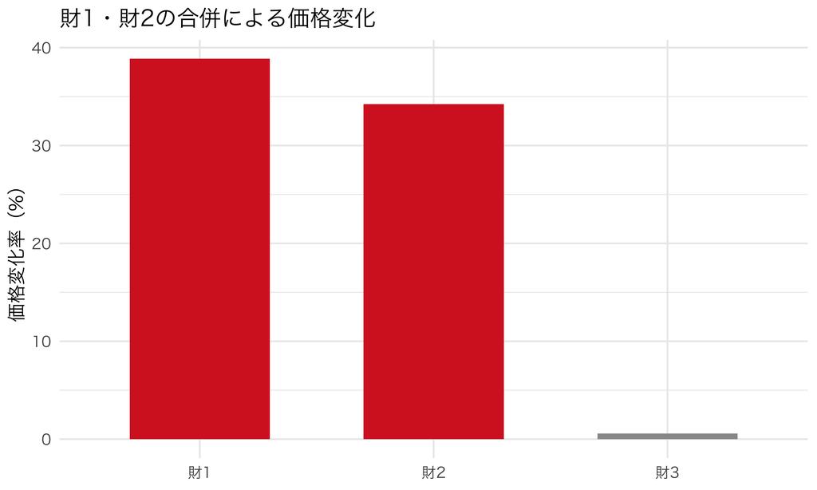

赤が合併当事者。限界費用は固定している。

```r
ggplot(merger_tbl, aes(product, price_change_pct,
                        fill = product %in% c("財1", "財2"))) +
  geom_col(width = 0.6, show.legend = FALSE) +
  scale_fill_manual(values = c("FALSE" = "grey60", "TRUE" = "#d62728")) +
  labs(title = "財1・財2の合併による価格変化", x = NULL, y = "価格変化率（%）")
```

この例では、合併する財1・2の価格が大きく上がり、非当事者の財3も少し値上げする。財1から財2へ移る需要を合併後の企業が取り込めるため、値上げの誘因が強まったのである。このような影響を**単独効果（unilateral effect）**と呼ぶ。

### 6.3 数量・利潤・消費者余剰も見る

市場の人数を $M=10{,}000$ 人とすると、販売数量は $q_j=Ms_j$、利潤は $(p_j-mc_j)q_j$ となる。固定費は含めない。合併で利益が増えても、消費者にとって望ましいとは限らないので、消費者余剰も見ておこう。

まず、前節で求めたシェアを数量に直し、1個あたりの利益を掛ける。

```r
market_size <- 10000
merger_tbl$quantity_pre <- market_size * s_pre
merger_tbl$quantity_post <- market_size * s_merger
merger_tbl$profit_pre <- (p_pre - mc_d) * merger_tbl$quantity_pre
merger_tbl$profit_post <- (p_merger - mc_d) * merger_tbl$quantity_post
knitr::kable(merger_tbl[, c("product", "quantity_pre", "quantity_post", "profit_pre", "profit_post")],
  digits = 1, col.names = c("商品", "合併前数量", "合併後数量", "合併前利潤", "合併後利潤"))
```

| 商品 | 合併前数量 | 合併後数量 | 合併前利潤 | 合併後利潤 |
| --- | --- | --- | --- | --- |
| 財1 | 2714.1 | 1741.4 | 3557.2 | 3886.7 |
| 財2 | 3598.5 | 2851.2 | 4745.3 | 5576.6 |
| 財3 | 1264.2 | 1884.4 | 1921.8 | 2903.6 |

数量は個数、利潤は価格と同じ金額単位である。このシミュレーションでは、価格1単位が何円に当たるかはまだ設定していない。最後に、計算結果そのものと、100円を1単位と読んだ場合の換算例を示す。

#### 期待効用を金額に直す

消費者余剰を考えるため、まず消費者 $i$ 一人に注目しよう。この人の価格係数 $\alpha_i$ を固定し、選択肢を「買わない」$j=0$ と財 $j=1,2,3$ とする。第6.2節の効用の式を、そのまま使う：

$$u_{ij}=\hat\delta_j+m(\hat a,\hat\sigma)p_j^{\mathrm{base}}
-\alpha_i p_j+\varepsilon_{ij}.$$

買わない場合の効用は $u_{i0}=\varepsilon_{i0}$ である。各選択肢の $\varepsilon_{ij}$ が互いに独立な標準Type I極値分布に従い、価格係数 $\alpha_i$ とも独立なとき、最もよい選択肢から得られる効用の期待値は、

$$\begin{aligned}
&E_{\varepsilon}\!\left[\max_{j=0,1,2,3}u_{ij}\mid\alpha_i\right]\\
&\quad=0.577\ldots+\log\left\{1+\sum_{j=1}^{3}\exp\!\left(
\hat\delta_j+m(\hat a,\hat\sigma)p_j^{\mathrm{base}}-\alpha_i p_j
\right)\right\}.
\end{aligned}$$

右辺の $0.577\ldots$ は標準Type I極値分布の平均（オイラー定数）である。その後ろの、指数を足し合わせてから対数を取った部分を **logsum** と呼ぶ。この期待値は、$i$ の価格係数を固定して、個別の $\varepsilon$ について平均したものである。期待値を取る前の各消費者は、それぞれの $\varepsilon$ を含めて、効用が最大になる選択肢を選ぶ。式が成り立つ理由は下のコラムで確認できる。

**ノート導出：Type I極値分布とlogsum**

$j=0$ を含む各 $\varepsilon_{ij}$ は互いに独立で、$\Pr(\varepsilon_{ij}\le e)=\exp(-e^{-e})$ である。最大の効用が $z$ 以下になるのは、**全ての選択肢**の効用が $z$ 以下のときなので、$\alpha_i$ を固定すると、

$$\begin{aligned}
&\Pr\!\left(\max_{j=0,1,2,3}u_{ij}\le z\mid\alpha_i\right)\\
&\quad=\prod_{j=0}^{3}\Pr(u_{ij}\le z\mid\alpha_i)\\
&\quad=\exp\!\left[-e^{-z}\left\{1+\sum_{j=1}^{3}\exp\!\left(
\hat\delta_j+m(\hat a,\hat\sigma)p_j^{\mathrm{base}}-\alpha_i p_j
\right)\right\}\right].
\end{aligned}$$

最後の式は、標準Type I極値分布を

$$\log\left\{1+\sum_{j=1}^{3}\exp\!\left(
\hat\delta_j+m(\hat a,\hat\sigma)p_j^{\mathrm{base}}-\alpha_i p_j
\right)\right\}$$

だけ右へずらした分布の累積分布関数である。したがって、その平均も $0.577\ldots$ にこのlogsumを足した値になる。式の中の1は、買わない選択肢に対応している。この性質と余剰への利用については [Train (2009), Chapter 3](https://eml.berkeley.edu/books/choice2nd/Ch03_p34-75.pdf) も参照。

次に、価格が合併前の $p^{\mathrm{base}}$ から合併後の $p^{\mathrm{new}}$ へ変わったときの期待効用の差を考える。定数 $0.577\ldots$ は前後で共通なので差を取ると消える。この差を各人の価格係数 $\alpha_i>0$ で割ると、その人の**金額単位の消費者余剰の変化**になる。価格が1単位上がると効用が $\alpha_i$ 下がるので、効用を金額に直すには $\alpha_i$ で割ればよい。所得の限界効用も $\alpha_i$ で、所得や合併によって変わらないという仮定を使っている。

random coefficient logitでは、$\alpha_i$ が人によって違う。そこで、この金額単位の変化を人々について平均する。$\alpha_i=\exp(\hat a+\hat\sigma\nu_i)$ とすると、1人あたりの消費者余剰の変化は

$$\Delta CS=E_i\left[
\frac{1}{\alpha_i}\log\!
\frac{1+\sum_{j=1}^{3}\exp\{\hat\delta_j+m(\hat a,\hat\sigma)p_j^{\mathrm{base}}-\alpha_i p_j^{\mathrm{new}}\}}
{1+\sum_{j=1}^{3}\exp\{\hat\delta_j+m(\hat a,\hat\sigma)p_j^{\mathrm{base}}-\alpha_i p_j^{\mathrm{base}}\}}
\right].$$

対数の中の比率は、分子が合併後、分母が合併前である。比率の対数は対数の差に等しいので、これは二つのlogsumの差を表している。両方で $\hat\delta_j+m(\hat a,\hat\sigma)p_j^{\mathrm{base}}$ は同じ値に保っている。

まず各人の $\alpha_i$ で割ってから平均する。平均の価格係数で一括して割るわけではない。計算では $\nu_i$ の120個の分位点を使ってこの平均を近似する。この平均には、**買わない人も含めた市場全体の消費者**が入る。

#### 市場全体で、いくら変わるのか

第4.1節で定義した `cs_value()` が、各人のlogsumを価格係数で割って平均する関数である。`market_outcomes()` は、その値に $M$ を掛けた市場全体の消費者余剰に加えて、販売数量 $M\sum_j s_j$ と企業利潤 $M\sum_j(p_j-mc_j)s_j$ も返す。

合併前後それぞれの消費者余剰の水準は、買わない場合の期待効用を基準として正規化している。つまり、期待最大効用から買わない場合の期待効用 $0.577\ldots$ を差し引き、logsumを $\alpha_i$ で割る。前後の差は上の式と一致する。

```r
outcomes_merger <- data.frame(
  outcome = c("販売数量の合計（個）", "企業利潤の合計（価格単位）", "消費者余剰（価格単位）"),
  before = market_outcomes(p_pre, mc_d, quality_d, a_d, sigma_d, nu, market_size),
  after = market_outcomes(p_merger, mc_d, quality_d, a_d, sigma_d, nu, market_size))
outcomes_merger$change <- outcomes_merger$after - outcomes_merger$before
knitr::kable(outcomes_merger, row.names = FALSE, digits = 1,
  col.names = c("指標", "合併前", "合併後", "変化"))
```

| 指標 | 合併前 | 合併後 | 変化 |
| --- | --- | --- | --- |
| 販売数量の合計（個） | 7576.9 | 6476.9 | -1099.9 |
| 企業利潤の合計（価格単位） | 10224.3 | 12367.0 | 2142.7 |
| 消費者余剰（価格単位） | 31360.4 | 27236.9 | -4123.5 |

この例では企業利潤の合計が増える一方、販売数量と消費者余剰は減る。消費者余剰は市場全体で 31,360.40 から 27,236.94 へ下がる。したがって、**1人平均で 0.41235 価格単位、1万人全体で 4,123.46 価格単位の減少（13.15%減）**である。これは効用の単位ではなく、価格と同じ金額の単位で測った損失である。

では、何円の損失なのか。元のシミュレーションは $p=2$ が2円なのか200円なのかを指定していないため、円での金額はそのままでは決まらない。**例えば価格1単位を100円と読むなら**、$p=2$ は200円を意味し、上の損失は **1人平均で約 41.23 円、1万人全体で約 412,346 円（約 41.2 万円）**になる。これは単位の読み方を明示した換算例であり、実際の市場で観測された円の損失ではない。

この金額は、全員が1回ずつ購入するかどうかを選ぶ、この市場での損失である。1年や1か月といった期間は設定していないので、年額や月額を意味しない。

### 6.4 補足：diversion ratio と UPP

合併後の均衡をすべて計算する前に、値上げ圧力を簡単に調べる指標もある。**diversion ratio** は、財 $j$ の小さな値上げで離れた顧客のうち、財 $k$ に移る割合である。

$$D_{j\to k}=-\frac{\partial s_k/\partial p_j}{\partial s_j/\partial p_j}.$$

財1の値上げによって財2へ多く移り、財2のマージンも大きいなら、合併後にその移動を取り込める価値は大きい。費用削減を考えない簡便な **UPP（upward pricing pressure）** は

$$\mathrm{UPP}_1=D_{1\to2}(p_2-mc_2)$$

で表される。UPPは値上げの誘因を測る指標であり、合併後の価格変化そのものではない。価格変化を知るには、他社の反応も含めて均衡を計算する必要がある。

```r
jac_pre <- rc_market(p_pre, quality_d, a_d, sigma_d, nu)$jac
diversion12 <- -jac_pre[2, 1] / jac_pre[1, 1]
upp1 <- diversion12 * (p_pre[2] - mc_d[2])
knitr::kable(data.frame(
  indicator = c("財1から財2へのdiversion ratio", "財1のUPP（費用削減なし）"),
  value = c(diversion12, upp1)), digits = 3,
  col.names = c("指標", "値"))
```

| 指標 | 値 |
| --- | --- |
| 財1から財2へのdiversion ratio | 0.576 |
| 財1のUPP（費用削減なし） | 0.759 |

**ノートビジネスの現場で：需要予測と価格の均衡**

自社が値上げしたときの販売数量を知りたいなら、価格を与えて需要を計算すればよい。競合も値付けを変える状況まで予測したいなら、その企業の行動についても仮定が必要になる。今回の合併分析では、需要とBertrandの価格設定を組み合わせて、全社の価格を一緒に求めた。実務の価格シミュレータを見るときも、どの価格を固定し、どの企業の反応を計算しているかを確認しよう。

**ヒント実証研究コーナー：Nevo (2001) — 高マージンは共謀か、ブランド力か**

**問い**：朝食シリアル業界は、価格が限界費用よりずっと高い（高マージン）。これは企業が裏で協調（共謀）しているからか、それとも製品差別化とブランド力の結果か。

**データ**：米国の朝食シリアル市場について、都市×四半期のスキャンパネル（POS）データを使う。ブランドごとの価格・シェア・製品特性が記録されている。

**識別戦略・モデル**：random coefficient logitで需要を推定し、供給側の行動仮説（単独最大化 vs 協調）のもとでマークアップを比べた。ブランド固定効果などで平均品質を制御するだけでなく、価格の内生性には他都市の同一ブランド平均価格（Hausman型IV）や流通費用のproxyなど複数のIVを用い、その仮定と頑健性を検討している。

**主要な発見**：観測される高マージンは、**共謀を仮定しなくても**、製品差別化とブランド力（強い選好）で説明できるという結果を得た。price-cost マージンはおおむね**4〜5割**と推定されたが、これは単独価格設定と矛盾しなかった。

**なぜこの回と繋がるか**：需要推定（random coefficient logit）と供給側モデル（Bertrand-Nash）を組み合わせて、観測できない限界費用や企業の行動を分析する例である。合併審査でも、現在の競争がどれくらい激しいかを調べるために、同じ枠組みを使う。

**ヒント実証研究コーナー：Miller and Weinberg (2017) — 合併後に協調的値上げは起きたか**

**問い**：2008年の MillerCoors 合弁（Miller と Coors のビール事業統合）の後、ビール業界で価格が上がったか。上がったとすれば、それは単独効果か、それとも残った大手（Anheuser-Busch と MillerCoors）の**協調的**な値上げか。

**データ**：合弁前後の米国ビール市場のスキャンデータを使う。ブランド×地域×時点の価格・シェアが記録されている。

**識別戦略・モデル**：random coefficient logit で需要を推定し、合弁前のデータで供給側モデルを較正する。その上で、単独 Nash による合弁後の価格予測を、実際の価格と比べる。実際の値上げが単独効果の予測を上回る分を、協調の強まりと解釈した。

**主要な発見**：合弁後、単独 Nash が予測する以上の価格上昇が観測され、**協調的価格上昇（部分的協調）**の証拠と解釈された。とくに Miller と Coors の主要ブランドで、合弁後に価格が数%上昇した。

**なぜこの回と繋がるか**：今回の合併シミュレーションで計算した単独効果は、合併後の結果を検証する際の比較基準にもなる。予測と実際の価格の差を調べることで、単独効果だけでは説明できない協調の可能性を検討する。第5回の合併審査の実務にも関わる分析である。

**ヒント実証研究コーナー：Adam, He and Zheng (2023, Management Science) — ロングテール市場の需要推定と機械学習**

**問い**：オンライン小売のように「売れる商品はごく一部、大半は販売数ゼロか極少（ロングテール）」という市場では、従来の random coefficient logit（BLP）はうまく推定できるか。

**データ・設定**：多数の商品を扱うオンラインマーケットプレイスで、販売数が0の商品が大量にある状況を分析する。BLPは販売数が正の商品しか扱えず、ゼロ販売をどう扱うかによってセレクションバイアスが生じる。

**識別戦略・モデル**：2段階推定を提案する。第1段階で、**random coefficient logit のデータ生成過程を模した構造を持つニューラルネットワーク（深層学習）**で全商品の市場シェアを予測する。第2段階で、その予測を使って観測シェアを再重み付けし、セレクションバイアスを補正しつつ構造モデルの因果的解釈を保つ。市場数について推定量の一致性を示した。

**主要な発見**：ロングテールのシミュレーションデータと実データの両方で、素朴なBLPより正確に消費者行動を推定できた。得られた推定値は、価格設定や品揃え（assortment）の意思決定に使える。

**なぜこの回と繋がるか**：この論文では、今回学んだBLPの枠組みに機械学習を組み合わせ、ECに多い、販売数がゼロまたは少数の商品に対応する。需要推定に使う情報を広げるために、機械学習の方法も組み合わせられる例である。

## 7. 個票データを使った需要推定：micro BLP

合併の予測では、当事者の商品どうしがどのくらい代替するかが重要だった。ところが、現在の市場シェアがよく合っているだけでは、その代替関係までうまく捉えられているとは限らない。第1節の3人の例でも、同じ販売数を再現する好みの構造が複数あり、値上げ後の需要は異なっていた。

ここまでは、市場ごとの価格・シェア・商品属性と、その外生的な変動を使って需要を推定してきた。これに「誰が買ったか」という情報を加えられないだろうか。例えば、同じ高価格帯の車でも、主に高所得世帯が買っているのか、それとも所得にあまり関係なく選ばれているのかで、所得と価格への反応の関係について得られる情報は違う。また、その車の購入者が第二希望としてどの車を挙げるかも、代替関係を考える手がかりになる。

このような**消費者ごとの情報を、集計データと組み合わせてBLPの推定に使う**方法を、ここではmicro BLPと呼ぶ。ここでいうmicroは、消費者ごとのデータを指す。[Berry, Levinsohn and Pakes (2004)](https://www.journals.uchicago.edu/doi/10.1086/379939) は、自動車の第一希望と第二希望、購入者の属性などの情報を組み合わせて需要を推定した。

### 7.1 所得をモデルに入れる

購入者の所得を観測できても、その所得が選択とどう関係するかをモデルに書かなければ、推定には使えない。そこで、この節では価格係数の式を少し拡張してみよう。所得を $y_i>0$、比較の基準となる所得を $y_{\mathrm{ref}}>0$ として、

$$\alpha_i
=\exp\left(a+\pi\log\frac{y_i}{y_{\mathrm{ref}}}+\sigma\nu_i\right),
\qquad \nu_i\sim N(0,1)$$

とする。ここでは $\nu_i$ は所得と独立と仮定する。$a$ は基準所得 $y_{\mathrm{ref}}$ の人のlog価格係数の平均である。これまでの対数正規の価格係数に、所得との関係を表す $\pi$ を加えただけである。例えば $\pi<0$ なら、同じ $\nu_i$ を持つ人を比べたとき、高所得の人ほど $\alpha_i$ が小さく、価格に反応しにくい。$\sigma\nu_i$ は、所得だけでは説明できない価格感応度の違いを表す。

このモデルなら、「高所得の人ほど高い商品を買う」というデータの特徴を、$\pi$ や $\sigma$ を選ぶ際の情報にできる。所得以外にも、家族の人数と車の大きさ、年齢と商品属性などの組み合わせが考えられる。どの個人属性をどの係数と結びつけるかは、知りたい代替関係と利用できるデータに応じて決める。

### 7.2 「購入者の平均所得」をモデルと比べる

一つの市場に注目し、市場を表す添字 $t$ は省略する。需要のパラメータをまとめて $\theta$ と書こう。所得や $\nu_i$ を与えたとき、消費者 $i$ が商品 $j$ を選ぶ確率を $s_{ij}(\theta)$ とする。これは、これまで計算してきた個人ごとのlogit確率である。

アンケートから、商品 $j$ の購入者の平均所得 $\bar y_j^{\mathrm{obs}}$ が分かったとする。モデルでは、この平均をどう計算すればよいだろうか。人口全体の所得をただ平均するだけではいけない。**商品 $j$ を買いやすい人ほど、購入者の中では大きな割合を占める**からである。そこで、各人の所得をその人の購入確率で重み付けする。

$$m_j^y(\theta)
=\frac{E[y_i s_{ij}(\theta)]}{E[s_{ij}(\theta)]}.$$

分子は所得と購入確率の積の平均、分母は商品 $j$ の市場シェアである。この比が、モデルの予測する「商品 $j$ の購入者の平均所得」になる。期待値は、その市場にいる消費者の所得や $\nu_i$ の分布について取る。

具体的に、所得が300万円、600万円、900万円の人が同じ人数ずついる市場を考えよう。ある商品を買う確率がそれぞれ0.1、0.3、0.6なら、購入者の平均所得は、

$$\frac{300\times0.1+600\times0.3+900\times0.6}{0.1+0.3+0.6}
=750\text{万円}$$

となる。人口全体の平均所得は600万円だが、この商品を買う人は高所得層に偏っているため、購入者の平均はそれより高くなる。

この計算をパラメータの候補ごとに行い、観測値とのずれ、

$$g_j^y(\theta)=\bar y_j^{\mathrm{obs}}-m_j^y(\theta)$$

を小さくしたい。市場シェアは合っていても、実際には平均750万円の購入者を、モデルが平均600万円と予測しているなら、購入者の構成を捉えられていない。このずれが、所得と好みの関係を見直すための追加の情報になる。

なお、モデルが平均を取るときに必要なのは、購入者だけでなく**その市場の消費者全体の所得分布**である。購入者のアンケートと人口全体のデータは、役割が違う。調査で特定の層が多く抽出されている場合には、その抽出方法に合わせた重みも必要になる。

**ヒント実証研究コーナー：Petrin (2002) — ミニバンを買ったのはどんな世帯か**

1984年に登場したミニバンは、消費者にどれだけの便益をもたらしたのだろうか。[Petrin (2002)](https://pricetheory.uchicago.edu/levitt/Papers/Petrin2002.pdf) は、自動車の価格・シェアなどに加え、Consumer Expenditure Surveyから得られる購入世帯の属性を使って、この問いを調べた。

同論文のTable 2では、1987–1992年の新車購入世帯の平均人数が**2.87人**なのに対し、ミニバン購入世帯では**3.86人**である。ミニバンのシェアだけでは分からない、「家族の多い世帯に選ばれている」という情報が加わる。こうした購入者属性と車種の関係をモデルにも再現させることで、家族構成と車への好みの関係を推定する。

その結果、個票の情報を使わないモデルと比べて、代替関係や新製品の便益の推定が変わった。ミニバンの販売数だけでなく、誰が買っていたかを説明することが、ミニバンのない世界の予測にも効いているのである。

### 7.3 「その商品がなければ何を選ぶか」も使う

購入者の属性に加え、第二希望を尋ねたデータがあるとしよう。例えば商品 $j$ の購入者に、「価格やほかの商品が同じで、$j$ だけ買えなかったら、何を選びますか」と聞く。商品 $k$ を選ぶと答えた人の割合を $q_{jk}^{\mathrm{obs}}$ とする。「何も買わない」も選択肢に含める。

この割合もモデルから計算できる。消費者 $i$ のタイプを固定するとlogitなので、$j$ を除いたときに $k$ を選ぶ確率は、

$$s_{ik}^{(-j)}(\theta)
=\frac{s_{ik}(\theta)}{1-s_{ij}(\theta)},\qquad k\ne j$$

となる。分母から $j$ の分を取り除き、残った選択肢の確率の合計を1に直している。Gumbelの効用ショックから得られる順位のモデルでは、タイプ $i$ の人が「第一希望 $j$、第二希望 $k$」となる確率は $s_{ij}(\theta)s_{ik}^{(-j)}(\theta)$ である。したがって、商品 $j$ の購入者に限った第二希望の割合は、

$$q_{jk}(\theta)
=\frac{E[s_{ij}(\theta)s_{ik}^{(-j)}(\theta)]}{E[s_{ij}(\theta)]}.$$

購入者の平均所得と同じく、$j$ を買いやすいタイプほど大きな重みを付けている。例えば「Aの購入者のうち、AがなければBを選ぶ人は60%」という観測値があれば、モデルにもその割合を再現させる。ここで使っているのは人口全体でのBの人気ではなく、**Aを選んだ人にとってのBの位置づけ**である。第一希望と第二希望を組み合わせる方法は、[Berry, Levinsohn and Pakes (2004)](https://www.journals.uchicago.edu/doi/10.1086/379939) の中心的な考え方の一つであり、上の確率の計算は[PyBLPの解説](https://pyblp.readthedocs.io/en/stable/background.html#micro-moments)でも確認できる。

### 7.4 追加した情報を推定に使う

購入者の平均所得や第二希望の割合のように、個票データから作った統計量を **micro moments** と呼ぶ。すべての個人の記録をそのまま推定に入れる代わりに、モデルと比べたい特徴を平均や比率として取り出している。

これまで使った需要のモーメントを、商品×市場の観測数 $N$ に対して、

$$g_D(\theta)=\frac{1}{N}\sum_{j,t}z_{jt}\xi_{jt}(\theta)$$

と書こう。micro momentsについても、観測値と予測値のずれを縦に並べたベクトル $g_M(\theta)$ を作る。例えば、

$$g_M(\theta)=
\begin{pmatrix}
\bar y_1^{\mathrm{obs}}-m_1^y(\theta)\\
q_{12}^{\mathrm{obs}}-q_{12}(\theta)\\
\vdots
\end{pmatrix}$$

である。両方をまとめて、

$$g(\theta)=
\begin{pmatrix}g_D(\theta)\\g_M(\theta)\end{pmatrix},
\qquad
\widehat\theta=\arg\min_\theta g(\theta)'Wg(\theta)$$

を解けばよい。$W$ は、それぞれのずれにどれだけ重みを付けるかを決める行列である。所得と選択割合では単位も推定の精度も違うので、その違いを考慮して重みを付ける。

計算の流れはBLPのままである。パラメータの候補を与えたら、まず市場シェアに合う平均効用を反転で求める。その上でIVの条件をどれだけ満たすかを調べ、さらに購入者の所得や第二希望もデータと比べる。**同じシェアを再現する候補でも、どんな人が買うかの予測が違えば、micro momentsとのずれに差がつく**のである。条件付き平均や比率を使う場合の目的関数は、厳密には最小距離推定の形だが、BLPの実装ではこれも含めてGMMと呼ぶことが多い（[PyBLPの解説](https://pyblp.readthedocs.io/en/stable/background.html#micro-moments)）。

### 7.5 合併予測へのつながりと、残る内生性の問題

micro momentsを加えて好みの分布の推定が変われば、価格を変えたときの需要の反応も変わる。すると、第6節で使った需要の価格微分、マークアップ、合併後の均衡価格も変わってくる。個票データを使う目的は、合併後の価格を直接尋ねることではない。**その予測の土台となる需要について、観測データで確かめられることを増やす**ことである。

ただし、第二希望の割合を、そのまま第6節のdiversion ratioに置き換えてはいけない。第二希望は商品がなくなったときの選択であり、diversion ratioは価格を少し上げたときの需要の移り方だった。価格に敏感な人ほど小さな値上げで動きやすいため、両者で重みの付く消費者が違う。第二希望を使ってモデルを推定した後、そのモデルから価格微分を計算する必要がある。

もう一つ、**個票データがあっても、価格の内生性はなくならない**。消費者の所得を詳しく観測していても、人気の高い商品ほど高く売られているなら、価格と未観測の需要ショック $\xi_{jt}$ は相関し得る。micro momentsを加えたからといって、IVの条件を捨ててよいわけではない。個票は好みの違いについて情報を足し、IVは価格と需要ショックを区別するための変動を与える。どちらの情報を何に使っているかを分けて考えよう。

**ヒント発展：Berry and Haile (2024) — 個票データが識別に加えるもの**

ここでは正規分布や対数正規分布を仮定して需要を推定した。では、特定の関数形を置かずに考えたとき、個票データから何が分かるのだろうか。[Berry and Haile (2024)](https://doi.org/10.3982/ECTA20731) は、消費者の選択と属性を観測できる状況で、差別化財需要の識別を分析している。

同じ市場の消費者を比べれば、商品ごとの需要ショック $\xi_{jt}$ は共通のまま、消費者の属性による選択の違いを調べられる。この情報を市場間の変動や価格の操作変数と組み合わせることで、識別に必要な操作変数の条件を緩められる場合がある。ただし、その結果には効用の構造、消費者属性の十分な変動、妥当な操作変数などの仮定が必要であり、個票があれば自動的に需要が分かるという話ではない。詳しくは[著者のワーキングペーパー](https://cowles.yale.edu/sites/default/files/2023-06/D2357.pdf)を参照。

## まとめ

**重要この回のポイント**

- 共通係数のlogitにも、効用ショックによる選択の違いはあった。random coefficient logitでは、さらに**属性への評価や価格への反応を人ごとに変える**。これにより、属性と結びついた代替関係を表せる。
- 個人の係数を固定すれば選択確率はlogitになる。その確率を人々について積分すると、市場シェアが得られる。同じ現在のシェアでも、好みの構造が違えば値上げ後の需要は異なり得る。
- **BLPは、第3回の反転とIVを異質性のある需要へ拡張する**。非線形パラメータの候補ごとに、シェアに合う平均効用を逆算し、OLSで平均係数と残差を求める。残差と追加の操作変数の無相関条件を使って、候補のパラメータを選ぶ。
- **推定した需要に企業の価格設定行動を加える**と、限界費用を逆算し、所有関係を変えた合併後の価格を予測できる。ここでは、需要を推定してから価格設定の条件を使った。
- **micro BLPでは、購入者の属性や第二希望もデータと比べる**。誰が買うか、何と何が代替するかについての追加情報が、異質性の推定と合併予測に役立つ。ただし、価格の内生性に対処する条件は引き続き必要である。

## 宿題

1. 第3節の交差弾力性のコードで、財1と財2の属性 `x_char` を「近い」から「遠い」に変えてみよう（例：`c(1.0, -0.9, -0.8)`）。財1と財2の代替関係がどう変わるかを、好みの異質性から説明してみよう。
2. 第6節の合併分析で、需要の推定値、合併前の価格、所有関係が、それぞれどの計算に使われているかを追ってみよう。合併後も固定しているものは何だろうか。
3. 第7節の3つの所得層の例で、購入確率をそれぞれ0.3、0.3、0.3に変えると、購入者の平均所得はいくらになるだろうか。元の例との違いを、「誰が買いやすいか」という言葉を使って説明してみよう。
4. 自分が知っている商品について、需要推定に使えそうなmicro momentを一つ考えよう。どんな個票データが必要で、モデルのどの好みの違いについて情報を与えるだろうか。

ブラウザで数値を変えてみたい人は、ブラウザ実験室も使ってみよう。coding課題は 課題4を参照。

## 次回予告

第5回は、公正取引委員会の方をお招きする**ゲスト講義**である。今回の需要推定や合併シミュレーションが、実際の企業結合審査でどのように使われるのかを伺う。企業や経済コンサルが提出する分析を、当局はどのように評価するのか。どんな代替関係を仮定し、何をデータで確かめているかを意識しながら聞いてみよう。

その後の第6回では、今回推定したような好みの分布を、個人の購買履歴からその人について学ぶために使う。市場全体のシェアを計算する場合と、個人の好みについて事後分布を求める場合を比べてみよう。第7回では、施策の配分、顧客価値、新商品の設計という目的ごとに必要な量を整理し、好みを測るためのコンジョイントの選択課題も考える。

## 参考文献

- Bresnahan, T. F. (1987). “Competition and Collusion in the American Automobile Industry: The 1955 Price War.” *The Journal of Industrial Economics*, 35(4), 457–482. [論文](https://doi.org/10.2307/2098583)
- Train, K. E. (2009). *Discrete Choice Methods with Simulation*, 2nd ed., Cambridge University Press, Chapters 3 and 6. [Chapter 6](https://eml.berkeley.edu/books/choice2nd/Ch06_p134-150.pdf)
- 上武康亮・遠山祐太・若森直樹・渡辺安虎『実証ビジネス・エコノミクス』日本評論社（第4章）。
- Nevo, A. (2000). “A Practitioner’s Guide to Estimation of Random-Coefficients Logit Models of Demand.” *Journal of Economics & Management Strategy*, 9(4), 513–548. [論文](https://doi.org/10.1111/j.1430-9134.2000.00513.x)
- Conlon, C., and Gortmaker, J. (2020). “Best practices for differentiated products demand estimation with PyBLP.” *The RAND Journal of Economics*, 51(4), 1108–1161. [論文](https://doi.org/10.1111/1756-2171.12352)
- Nevo, A. (2001). “Measuring Market Power in the Ready-to-Eat Cereal Industry.” *Econometrica*, 69(2), 307–342.
- Berry, S., Levinsohn, J., and Pakes, A. (1995). “Automobile Prices in Market Equilibrium.” *Econometrica*, 63(4), 841–890.
- Berry, S., Levinsohn, J., and Pakes, A. (2004). “Differentiated Products Demand Systems from a Combination of Micro and Macro Data: The New Car Market.” *Journal of Political Economy*, 112(1), 68–105. [論文](https://www.journals.uchicago.edu/doi/10.1086/379939)
- Werden, G. J., and Froeb, L. M. (1994). “The Effects of Mergers in Differentiated Products Industries: Logit Demand and Merger Policy.” *Journal of Law, Economics, & Organization*, 10(2), 407–426.
- Petrin, A. (2002). “Quantifying the Benefits of New Products: The Case of the Minivan.” *Journal of Political Economy*, 110(4), 705–729. [論文](https://pricetheory.uchicago.edu/levitt/Papers/Petrin2002.pdf)
- Miller, N. H., and Weinberg, M. C. (2017). “Understanding the Price Effects of the MillerCoors Joint Venture.” *Econometrica*, 85(6), 1763–1791.
- Berry, S. T., and Haile, P. A. (2024). “Nonparametric Identification of Differentiated Products Demand Using Micro Data.” *Econometrica*, 92(4), 1135–1162. [論文](https://doi.org/10.3982/ECTA20731)
- PyBLP Documentation. “Micro Moments” and “Second Choice Micro Moments.” [解説](https://pyblp.readthedocs.io/en/stable/background.html#micro-moments)
- Adam, H., He, P., and Zheng, F. (2023). “Machine Learning for Demand Estimation in Long Tail Markets.” *Management Science*, 70(8), 5040–5065. https://doi.org/10.1287/mnsc.2023.4893